# A systematic map of syntheses on anthropogenic noise impacts on wildlife: evidence gaps, policy attention, and quality appraisal - Code to replicate the figures and analysis

This tutorial reproduces the analyses and figures from the accompanying datasets. Download this HTML file and open it in a browser to view it offline. Expand a code section to inspect the calculations. Re-running the analysis requires R and the repository; viewing this tutorial does not.

# Setup

```r
# Install these packages before rendering the tutorial.
figure_packages <- c(
  "tidyverse", "here", "paletteer", "scales", "treemapify",
  "bibliometrix", "ComplexUpset", "patchwork", "wordcloud2",
  "sf", "rnaturalearthdata", "rnaturalearth", "ggalluvial",
  "circlize", "countrycode", "png", "ragg", "ggthemes", "knitr", "base64enc", "rmarkdown"
)
missing_packages <- figure_packages[
  !vapply(figure_packages, requireNamespace, quietly = TRUE, FUN.VALUE = logical(1))
]
if (length(missing_packages)) {
  stop("Install the required packages before rendering: ",
       paste(missing_packages, collapse = ", "))
}
invisible(lapply(figure_packages, library, character.only = TRUE))
knitr::opts_chunk$set(message = FALSE, warning = FALSE, results = "hide",
                      fig.width = 12, fig.height = 9, dpi = 150, out.width = "100%")
# Set each figure’s proportions. Export files only when export_figures is TRUE.
knitr::opts_hooks$set(label = function(options) {
  sizes <- list(
    "figure-1-systematic-map-evidence-matrix-7" = c(18, 12),
    "figure-3-bibliometric-analysis-4" = c(10, 15),
    "figure-5-ceesat-scores-ceesat-question-scores-all-synth-1" = c(15, 9),
    "figure-s3-synthesis-characteristics-and-content-mapping-6" = c(15, 10),
    "figure-s4-assemble" = c(8, 10.35),
    "figure-s5-academic-citation-count-and-the-three-most-ci-1" = c(7.2, 5),
    "figure-s6-policy-analysis-alluvial-plot-all-variables-1" = c(10, 10),
    "figure-s7-policy-citation-counts-by-synthesis-publicati-1" = c(7.2, 5),
    "figure-s8-policy-trends-4" = c(11, 12),
    "see-plots-1" = c(18, 15),
    "figure-s10-geographical-distribution-of-policy-3" = c(11, 8),
    "figure-s11-ceesat-scores-cited-and-not-cited-in-policy-2" = c(16, 9)
  )
  z <- sizes[[options$label]]
  if (!is.null(z)) { options$fig.width <- z[1]; options$fig.height <- z[2] }
  options
})

# Set the project root explicitly, including when here was loaded in another project.
here::i_am("R/Wildlife_syntheses_figures_.Rmd")
```

## Figure formatting and export helpers

```r
# Export main figures as 600-dpi TIFF/PNG files and PDFs with embedded fonts.
export_main_figure <- function(plot, number, stem, width, height,
                               project_root = here::here()) {
  if (!isTRUE(params$export_figures)) return(invisible(NULL))
  final <- file.path(project_root, "Figures", "Final_figures")
  raw <- final
  dir.create(final, recursive = TRUE, showWarnings = FALSE)
  dir.create(file.path(final, "tiff"), recursive = TRUE, showWarnings = FALSE)
  filename <- paste0("Figure_", number, "_", stem)
  ggplot2::ggsave(file.path(final, "tiff", paste0("Figure", number, "_", stem, ".tiff")), plot,
    width = width, height = height, units = "in", dpi = 600,
    device = ragg::agg_tiff, compression = "lzw", bitsize = 8, bg = "white")
  ggplot2::ggsave(file.path(final, paste0(filename, ".png")), plot,
    width = width, height = height, units = "in", dpi = 600,
    device = ragg::agg_png, bg = "white")
  # Quartz embeds fonts on macOS without requiring a separate XQuartz install.
  pdf_device <- if (identical(Sys.info()[["sysname"]], "Darwin")) {
    function(filename, width, height, bg, ...) {
      grDevices::quartz(type = "pdf", file = filename,
                        width = width, height = height, bg = bg)
    }
  } else grDevices::cairo_pdf
  ggplot2::ggsave(file.path(raw, paste0(filename, ".pdf")), plot,
    width = width, height = height, units = "in",
    device = pdf_device, bg = "white")
  message("Exported Figure ", number, ": ", width, " x ", height,
          " in; RGB TIFF/PNG 600 dpi and font-embedded PDF.")
  invisible(file.path(final, "tiff", paste0("Figure", number, "_", stem, ".tiff")))
}

# Export supplementary figures when export_figures is TRUE.
save_supplementary_figure <- function(filename, ...) {
  if (!isTRUE(params$export_figures)) return(invisible(NULL))
  dir.create(dirname(filename), recursive = TRUE, showWarnings = FALSE)
  ggplot2::ggsave(filename, ...)
}

dir.create(here("Figures", "Final_figures"), recursive = TRUE, showWarnings = FALSE)
main_figure_widths <- c(figure_1 = 18, figure_3 = 10)
main_panel_letter <- function() {
  element_text(
    family = "Helvetica", face = "bold",
    size = 24,
    colour = "#243746"
  )
}
```

# Load data

```r
read_ceesat_csv <- function(path) {
  read.csv(path, colClasses = "character", check.names = FALSE,
           na.strings = NULL, strip.white = FALSE, fileEncoding = "UTF-8-BOM")
}

transform_ceesat <- function(raw) {
  metadata <- c("study_id", "study_type_title_abstract", "doi", "cited_in_policy")
  questions <- c("1.1", "2.1", "3.1", "3.2", "4.1", "4.2", "4.3",
                 "5.1", "5.2", "6.1", "6.2", "6.3", "7.1", "7.2", "7.3", "8.1")
  if (anyDuplicated(names(raw)) || !all(metadata %in% names(raw))) {
    stop("Dataset4 has duplicate column names or is missing required metadata.")
  }
  if (!nrow(raw) || anyNA(raw$study_id) || any(!nzchar(trimws(raw$study_id))) ||
      anyDuplicated(raw$study_id)) stop("Dataset4 must have unique, nonblank study IDs.")
  if (anyNA(raw$cited_in_policy) ||
      !all(raw$cited_in_policy %in% c("0", "1"))) {
    stop("cited_in_policy must contain only 0 and 1.")
  }
  question_cols <- grep("^[0-9]+[.][0-9]+:", names(raw), value = TRUE)
  question_ids <- sub(":.*$", "", question_cols)
  if (anyDuplicated(question_ids) || !setequal(question_ids, questions)) {
    stop("Dataset4 must contain exactly the 16 expected CEESAT question columns.")
  }
  question_cols <- question_cols[match(questions, question_ids)]
  scores <- c("Red (0)" = 0L, "Amber (1)" = 1L,
              "Green (3)" = 3L, "Gold (4)" = 4L)
  out <- raw[metadata]
  for (i in seq_along(questions)) {
    labels <- trimws(raw[[question_cols[i]]])
    bad <- is.na(labels) | !(labels %in% names(scores))
    if (any(bad)) {
      stop(sprintf("Unknown/missing rating for CEESAT%s: %s", questions[i],
                   paste(raw$study_id[bad], collapse = ", ")))
    }
    out[[paste0("CEESAT", questions[i])]] <- unname(scores[labels])
  }

  # Dataset4's Total Score is blank in the supplied source. Recompute from all
  # 16 items (maximum 64); do not rescale, impute, or use that source total.
  out$raw_score <- rowSums(out[paste0("CEESAT", questions)])
  out
}

validate_ceesat <- function(generated, reference) {
  if (!identical(names(generated), names(reference)) ||
      nrow(generated) != nrow(reference)) {
    stop("Generated and reference datasets have different dimensions or columns.")
  }
  # Check every cell and row order, including metadata and DOI whitespace.
  differences <- lapply(names(reference), function(column) {
    actual <- as.character(generated[[column]])
    expected <- as.character(reference[[column]])
    bad <- which(is.na(actual) != is.na(expected) |
                   (!is.na(actual) & !is.na(expected) & actual != expected))
    if (!length(bad)) return(NULL)
    data.frame(row = bad, study_id = generated$study_id[bad], column = column,
               generated = actual[bad], reference = expected[bad])
  })
  differences <- do.call(rbind, differences)
  if (!is.null(differences)) {
    print(differences, row.names = FALSE)
    stop("Generated values differ from the manual reference; no output was written.")
  }
  invisible(TRUE)
}

# Reconstruct in memory and validate every cell against the supplied final Dataset5.
ceesat_generated <- transform_ceesat(read_ceesat_csv(
  here("Data", "Dataset4_ceesat_assessments.csv")))
validate_ceesat(ceesat_generated, read_ceesat_csv(
  here("Data", "Dataset5_ceesat_processed.csv")))

# Load the final datasets after validation; no source files are overwritten.
map <- read_csv(here("Data", "Dataset1_map_data_extraction.csv"))
biblio <- read_csv(here("Data", "Dataset2_bibliometric_data.csv"))
dat_policy <- read.csv(here("Data", "Dataset_3_policy_data_extraction.csv"))
pol_ci <- read_csv(here("Data", "Dataset_3.1_policy_citation_counts_PlumX.csv"))
dat_ceesat <- read.csv(here("Data", "Dataset5_ceesat_processed.csv"))
```

# Figure 1: Systematic-map evidence matrix

## Setup and shared helpers

```r
figure1_panel_letter <- function() {
  element_text(family = "Helvetica", face = "bold", size = 26, colour = "#243746")
}

n_syntheses <- n_distinct(map$study_id)

# Panel A uses grey and muted magenta; panel B uses a blue-grey gradient.
colours <- c(
  ink = "#243746",
  muted_ink = "#52636F",
  narrative = "#BDBDBD",
  quantitative = "#A34F78",
  marine = "#667A93",
  urban = "#AD8EAF",
  invertebrate = "#53917E",
  freshwater = "#A2BAB6",
  plum = "#8A4A82",
  breadth_multiple = "#243746",
  terrestrial = "#A8A17B",
  slate = "#8A8F98",
  breadth_single = "#DCE7ED",
  pale_tile = "#EDF2F5",
  paper = "white",
  line = "#CBD3D8"
)

split_categories <- function(data, variable) {
  data %>%
    select(study_id, {{ variable }}) %>%
    separate_rows({{ variable }}, sep = ",") %>%
    mutate({{ variable }} := str_trim({{ variable }})) %>%
    filter(!is.na({{ variable }}), {{ variable }} != "") %>%
    distinct()
}

# Label helper: "Transportation (37)".
with_total <- function(label, n) paste0(label, " (", n, ")")


base_size <- 20

theme_map <- function() {
  theme_minimal(base_size = base_size) +
    theme(
      plot.background = element_rect(fill = "transparent", colour = NA),
      panel.background = element_rect(fill = "transparent", colour = NA),
      panel.grid = element_blank(),
      plot.tag = figure1_panel_letter(),
      plot.tag.position = c(0, 1),
      axis.text = element_text(colour = colours["ink"], size = base_size - 0.5),
      axis.title = element_text(colour = colours["muted_ink"], size = base_size - 1),
      legend.text = element_text(colour = colours["muted_ink"], size = base_size - 1.5),
      legend.title = element_text(colour = colours["muted_ink"], size = base_size - 1.5),
      plot.margin = margin(10, 12, 10, 12)
    )
}
```

## Panel A: Publication year and synthesis approach

```r
approach_by_year <- map %>%
  transmute(
    study_id,
    year,
    approach = if_else(
      str_to_lower(str_trim(quantitative)) == "yes",
      "Quantitative",
      "Narrative/Descriptive"
    )
  ) %>%
  distinct() %>%
  count(year, approach, name = "n") %>%
  complete(
    year = seq(min(map$year, na.rm = TRUE), max(map$year, na.rm = TRUE)),
    approach = c("Narrative/Descriptive", "Quantitative"),
    fill = list(n = 0)
  )

approach_counts <- approach_by_year %>%
  summarise(n = sum(n), .by = approach)

approach_labels <- set_names(
  with_total(approach_counts$approach, approach_counts$n),
  approach_counts$approach
)

year_totals <- approach_by_year %>%
  summarise(n = sum(n), .by = year) %>%
  filter(n > 0)

panel_a <- ggplot(approach_by_year, aes(x = year, y = n, fill = approach)) +
  geom_col(width = 0.62) +
  geom_text(
    data = year_totals,
    aes(x = year, y = n, label = n),
    inherit.aes = FALSE,
    vjust = -0.6,
    size = base_size / .pt * 0.92,
    colour = colours["muted_ink"]
  ) +
  scale_fill_manual(
    values = c(
      "Narrative/Descriptive" = unname(colours["narrative"]),
      "Quantitative" = unname(colours["quantitative"])
    ),
    labels = approach_labels,
    name = NULL
  ) +
  scale_x_continuous(
    breaks = seq(min(approach_by_year$year), max(approach_by_year$year), by = 1),
    expand = expansion(mult = 0.015)
  ) +
  scale_y_continuous(
    breaks = c(0, 5, 10),
    expand = expansion(mult = c(0, 0.45))
  ) +
  labs(tag = "A", y = "Syntheses", x = NULL) +
  theme_map() +
  theme(
    panel.grid.major.y = element_blank(),
    axis.text.x = element_text(size = 16),
    axis.line.x = element_line(colour = colours["line"], linewidth = 0.3),
    axis.title.y = element_text(margin = margin(r = 12)),
    legend.position = "top",
    legend.justification = "left",
    legend.direction = "horizontal",
    legend.key.size = unit(11, "pt")
  )
```

## Panel B: Noise source × biological outcome evidence matrix

```r
noise_long <- split_categories(map, noise_source)
outcome_long <- split_categories(map, outcome_category)

noise_totals <- noise_long %>%
  count(noise_source, name = "total") %>%
  arrange(desc(total))

outcome_totals <- outcome_long %>%
  count(outcome_category, name = "total") %>%
  arrange(desc(total))

crosstab <- noise_long %>%
  inner_join(outcome_long, by = "study_id", relationship = "many-to-many") %>%
  count(noise_source, outcome_category, name = "n") %>%
  complete(
    noise_source = noise_totals$noise_source,
    outcome_category = outcome_totals$outcome_category,
    fill = list(n = 0)
  ) %>%
  left_join(noise_totals, by = "noise_source") %>%
  left_join(outcome_totals, by = "outcome_category") %>%
  mutate(
    noise_label = factor(
      with_total(noise_source, total.x),
      levels = rev(with_total(noise_totals$noise_source, noise_totals$total))
    ),
    outcome_label = factor(
      with_total(outcome_category, total.y),
      levels = with_total(outcome_totals$outcome_category, outcome_totals$total)
    ),
    # White numerals only where the tile is dark enough to carry them.
    label_colour = if_else(n >= 13, "#FFFFFF", unname(colours["ink"]))
  )

panel_b <- ggplot(crosstab, aes(x = outcome_label, y = noise_label, fill = n)) +
  geom_tile(colour = colours["paper"], linewidth = 1.4) +
  geom_text(
    aes(label = n, colour = label_colour),
    size = base_size / .pt * 0.95
  ) +
  scale_colour_identity() +
  scale_fill_gradient(
    low = colours["pale_tile"],
    high = colours["ink"],
    name = "Syntheses per combination",
    guide = guide_colourbar(
      title.position = "top",
      title.vjust = 0.9,
      barwidth = unit(180, "pt"),
      barheight = unit(7, "pt"),
      ticks = FALSE
    )
  ) +
  scale_x_discrete(position = "top", expand = expansion(0)) +
  scale_y_discrete(expand = expansion(0)) +
  labs(tag = "B",
       x = NULL, y = NULL) +
  theme_map() +
  theme(
    axis.text.x.top = element_text(angle = 40, hjust = 0, vjust = 0,
                                   colour = colours["ink"]),
    legend.position = "bottom",
    legend.justification = "left",
    legend.direction = "horizontal",
    legend.margin = margin(t = 10)
  )
```

## Panel C: Taxonomic scope

```r
vertebrate_taxa <- c("Aves", "Mammalia", "Reptilia", "Fish", "Amphibia")
invertebrate_taxa <- c(
  "Invertebrates", "Arthropoda", "Mollusca", "Cnidaria",
  "Echinodermata", "Annelida", "Bryozoa"
)

taxonomic_membership <- map %>%
  select(study_id, scope_taxon) %>%
  separate_rows(scope_taxon, sep = ",") %>%
  mutate(
    scope_taxon = str_to_title(str_trim(scope_taxon)),
    group = case_when(
      scope_taxon %in% vertebrate_taxa ~ "Vertebrate",
      scope_taxon %in% invertebrate_taxa ~ "Invertebrate",
      TRUE ~ NA_character_
    )
  ) %>%
  filter(!is.na(group)) %>%
  distinct(study_id, group)

# "Mixed" is the overlap of the two groups, not a third exclusive group: those
# syntheses are also counted in the Vertebrate and Invertebrate bars.
taxonomic_overlap <- taxonomic_membership %>%
  count(study_id) %>%
  summarise(n = sum(n == 2)) %>%
  pull(n)

taxonomic_counts <- taxonomic_membership %>%
  count(group, name = "n") %>%
  bind_rows(tibble(group = "Mixed", n = taxonomic_overlap)) %>%
  mutate(group = factor(group, levels = c("Mixed", "Invertebrate", "Vertebrate")))

panel_c <- ggplot(taxonomic_counts, aes(x = n, y = group, fill = group)) +
  geom_col(width = 0.62) +
  geom_text(
    aes(label = n),
    hjust = -0.35,
    size = base_size / .pt * 0.95,
    colour = colours["ink"]
  ) +
  scale_fill_manual(
    values = c(
      "Vertebrate" = unname(colours["plum"]),
      "Invertebrate" = unname(colours["invertebrate"]),
      "Mixed" = unname(colours["slate"])
    ),
    guide = "none"
  ) +
  scale_x_continuous(limits = c(0, n_syntheses + 5), expand = expansion(mult = c(0, 0.02))) +
  scale_y_discrete(expand = expansion(add = 0.5)) +
  labs(tag = "C", x = NULL, y = NULL) +
  theme_map() +
  theme(
    axis.text.x = element_blank()
  )
```

## Panel D: Environmental scope

```r
environment_counts <- split_categories(map, ecosystem_type) %>%
  count(ecosystem_type, name = "n") %>%
  arrange(n) %>%
  mutate(ecosystem_type = fct_inorder(ecosystem_type))

panel_d <- ggplot(environment_counts, aes(x = n, y = ecosystem_type, fill = ecosystem_type)) +
  geom_col(width = 0.62) +
  geom_text(
    aes(label = n),
    hjust = -0.35,
    size = base_size / .pt * 0.95,
    colour = colours["ink"]
  ) +
  scale_fill_manual(
    values = c(
      "Marine" = unname(colours["marine"]),
      "Terrestrial" = unname(colours["terrestrial"]),
      "Freshwater" = unname(colours["freshwater"]),
      "Urban" = unname(colours["urban"])
    ),
    guide = "none"
  ) +
  scale_x_continuous(limits = c(0, n_syntheses), expand = expansion(mult = c(0, 0.02))) +
  scale_y_discrete(expand = expansion(add = 0.5)) +
  labs(tag = "D", x = NULL, y = NULL) +
  theme_map() +
  theme(
    axis.text.x = element_blank()
  )
```

## Panel E: Coverage breadth

```r
breadth_of <- function(long_data, variable, label) {
  long_data %>%
    count(study_id, name = "categories") %>%
    summarise(
      Multiple = sum(categories > 1),
      Single = sum(categories == 1),
      assignments = sum(categories)
    ) %>%
    mutate(dimension = label, mean_categories = assignments / n_syntheses)
}

breadth <- bind_rows(
  breadth_of(noise_long, noise_source, "Noise sources"),
  breadth_of(outcome_long, outcome_category, "Outcomes"),
  breadth_of(split_categories(map, ecosystem_type), ecosystem_type, "Environments"),
  breadth_of(taxonomic_membership, group, "Taxon groups")
) %>%
  mutate(dimension = fct_inorder(dimension) %>% fct_rev())

breadth_long <- breadth %>%
  pivot_longer(c(Multiple, Single), names_to = "breadth", values_to = "n") %>%
  mutate(breadth = factor(breadth, levels = c("Multiple", "Single")))

panel_e <- ggplot(breadth_long, aes(x = n, y = dimension, fill = breadth)) +
  geom_col(width = 0.6, position = position_stack(reverse = TRUE)) +
  geom_text(
    aes(label = n, colour = breadth),
    position = position_stack(vjust = 0.5, reverse = TRUE),
    size = base_size / .pt * 0.88
  ) +
  scale_fill_manual(
    values = c(
      "Multiple" = unname(colours["breadth_multiple"]),
      "Single" = unname(colours["breadth_single"])
    ),
    labels = c("Multiple" = "Multiple categories", "Single" = "Single"),
    name = NULL
  ) +
  scale_colour_manual(
    values = c("Multiple" = "#FFFFFF", "Single" = unname(colours["muted_ink"])),
    guide = "none"
  ) +
  scale_x_continuous(
    limits = c(0, n_syntheses),
    expand = expansion(mult = c(0, 0.02))
  ) +
  guides(fill = guide_legend(ncol = 1)) +
  labs(tag = "E", x = NULL, y = NULL) +
  theme_map() +
  theme(
    axis.text.x = element_blank(),
    legend.position = "bottom",
    legend.justification = "left",
    legend.direction = "horizontal",
    legend.key.size = unit(11, "pt")
  )
```

## Assemble and save Figure 1

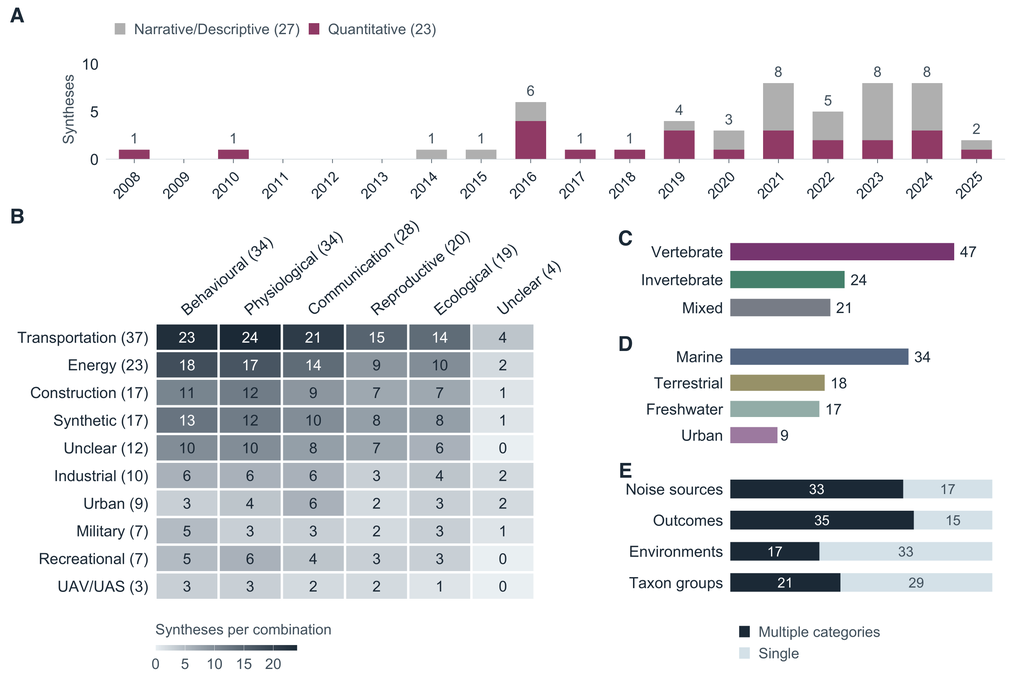

```r
panel_a <- panel_a + scale_y_continuous(breaks=c(0,5,10),
 limits=c(0,10.5),expand=expansion(mult=c(0,0))) + theme(
 axis.text.x=element_text(size=18,angle=45,hjust=1,vjust=1),
 axis.ticks.x=element_line(colour=colours["muted_ink"],linewidth=0.4),
 axis.ticks.length.x=unit(5,"pt"),
 axis.title.y=element_text(margin=margin(r=6)),
 plot.margin=margin(8,14,8,70),legend.key.size=unit(16,'pt'))
panel_b <- panel_b + theme(plot.margin=margin(10,42,4,12))
panel_c <- panel_c + theme(plot.margin=margin(32,18,18,12))
panel_d <- panel_d + theme(plot.margin=margin(10,18,18,12))
panel_e <- panel_e + theme(plot.margin=margin(10,18,4,12),legend.key.size=unit(16,'pt'))
right_column <- wrap_plots(panel_c,panel_d,panel_e,ncol=1,heights=c(.8,1,1.25))
# Explicit white gutter: labels from B cannot intrude into the right column.
body <- wrap_plots(wrap_elements(full=panel_b),plot_spacer(),wrap_elements(full=right_column),
 nrow=1,widths=c(10.1,.65,7.25))
# Keep the graph inset while positioning its panel letter at the outer left margin.
panel_a <- panel_a + labs(tag=NULL)
panel_a_wrapper <- wrap_elements(full=panel_a) + labs(tag='A') +
 theme(plot.tag=figure1_panel_letter(),plot.tag.position=c(0.005,0.965),
       plot.margin=margin(0,0,0,0))
figure_1 <- wrap_plots(panel_a_wrapper,body,ncol=1,heights=c(3.65,8.35)) +
 plot_annotation(theme=theme(plot.margin=margin(10,10,10,10)))

# Wide layout, exported directly at 600 dpi when requested.
export_main_figure(figure_1, 1, "systematic_map_evidence_matrix", 18, 12)
figure_1
```

# Figure 2: Taxonomic groups

The treemap below is the reproducible, code-generated base of Figure 2. The author’s original animal illustrations and editable artwork are not distributed with this repository. The submitted composition was assembled manually.

## Panel A: Taxonomic distribution TREEMAP

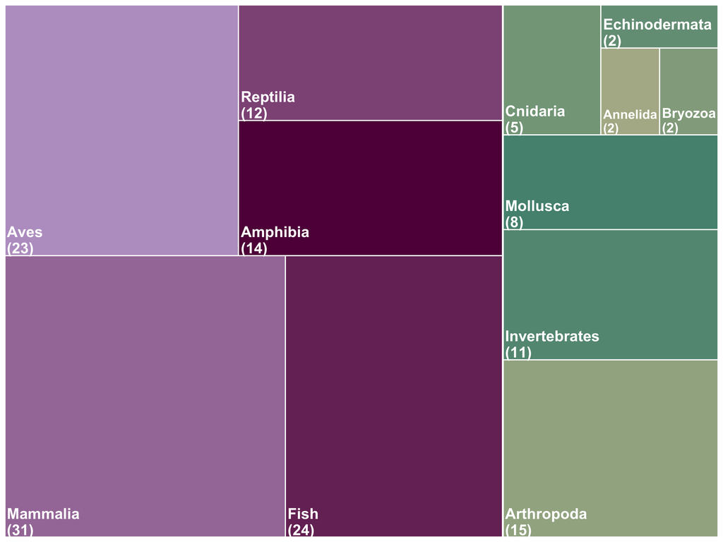

```r
# Split and clean taxa
taxon_long4 <- map %>%
  separate_rows(scope_taxon, sep = ",") %>%
  mutate(
    scope_taxon = str_trim(scope_taxon),
    scope_taxon = str_to_title(scope_taxon)
  )

# Get unique study counts per taxon (no double-counting)
taxon_counts3 <- taxon_long4 %>%
  distinct(study_id, scope_taxon) %>%
  group_by(scope_taxon) %>%
  summarise(mentions = n(), .groups = "drop")

# Assign group and subgroup
 vertebrates <- c("Aves", "Mammalia", "Reptilia", "Fish", "Amphibia")

taxon_counts3 <- taxon_counts3 %>%
  mutate(
    group = if_else(scope_taxon %in% vertebrates, "Vertebrate", "Invertebrate"),
    subgroup = scope_taxon
  ) %>%
  filter(mentions > 0)

# Assign pastel green and pastel purple gradients
vertebrate_subgroups <- vertebrates
invertebrate_subgroups <- setdiff(unique(taxon_counts3$subgroup), vertebrates)

# Assign colours for each group: purple for vertebrates and green for invertebrates
pal_vertebrate <- scales::colour_ramp(c("#BBA0CA", "#600047"))(seq(0,1,length.out=length(vertebrate_subgroups)))
pal_invertebrate <- scales::colour_ramp(c("#B1B695", "#53917E"))(seq(0,1,length.out=length(invertebrate_subgroups)))

# Count data
taxon_counts3 <- taxon_counts3 %>%
  mutate(
    fill_color = case_when(
      group == "Vertebrate" ~ pal_vertebrate[match(subgroup, vertebrate_subgroups)],
      group == "Invertebrate" ~ pal_invertebrate[match(subgroup, invertebrate_subgroups)]
    ),
    label = paste0(scope_taxon, "\n(", mentions, ")")
  )

# Plot treemap (no subgroup label, just colored borders)
figure_2 <- ggplot(taxon_counts3, aes(area = mentions, fill = fill_color, label = label, subgroup = group)) +
  geom_treemap(color = "white", size = 1.8) +
  geom_treemap_subgroup_border(color = "white", size = 3) +   # Group borders
  geom_treemap_text(
    fontface = "bold", colour = "White",
    place = "bottomleft", grow = FALSE, reflow = TRUE, min.size = 6
  ) +
  scale_fill_identity() +
  theme(
    plot.title = element_text(face = "bold", size = 20, hjust = 0.5),
    plot.subtitle = element_text(size = 13, hjust = 0.5),
    legend.position = "none",
    panel.background = element_rect(fill = "white", colour = NA),
    plot.background = element_rect(fill = "white", colour = NA)
  )

# Show figure
figure_2
```

```r
# The submitted Figure 2 is a manual composition and is not overwritten.
if (isTRUE(params$export_figures)) {
  ggplot2::ggsave(here("Figures", "Final_figures", "Figure_2_taxonomic_scope_code_base.png"),
                 figure_2, width = 10, height = 7, dpi = 600, bg = "white")
}
```

# Figure 3: Bibliometric analysis

## Setup and country-name cleaning

```r
# Panel A uses the first author's first listed affiliation country.
# Panel B uses countries from ALL authors' affiliations, counted once per paper.
# Scopus separates authors with semicolons but concatenates an author's multiple
# affiliations with commas. The last country can therefore be a later affiliation.
# Match complete country tokens against this record's separate affiliation list,
# and return the first country in the first author's block (export order).
first_author_first_country <- function(authors_with_affiliations, affiliations) {
  stopifnot(length(authors_with_affiliations) == length(affiliations))
  normalise <- function(x) tolower(sub("\\.$", "", trimws(x)))

  vapply(seq_along(authors_with_affiliations), function(i) {
    if (is.na(authors_with_affiliations[i]) || is.na(affiliations[i])) {
      stop("Missing affiliation metadata at record ", i)
    }
    author_block <- strsplit(authors_with_affiliations[i], ";", fixed = TRUE)[[1]][1]
    # The first two fields are the author's surname and given names.
    fields <- trimws(strsplit(author_block, ",", fixed = TRUE)[[1]])[-c(1, 2)]
    record_affiliations <- strsplit(affiliations[i], ";", fixed = TRUE)[[1]]
    countries <- vapply(record_affiliations, function(x) {
      tail(trimws(strsplit(x, ",", fixed = TRUE)[[1]]), 1)
    }, character(1))
    matches <- which(normalise(fields) %in% normalise(countries))
    if (!length(matches)) {
      stop("Cannot identify the first author's first affiliation country at record ", i)
    }
    fields[matches[1]]
  }, character(1))
}


# Direct Scopus and bibliometrix routes give the same international country pairs.
USE_BIBLIOMETRIX <- FALSE


colours <- c(
  ink = "#243746",
  muted_ink = "#52636F",
  paper = "white",
  land = "#E3E6E4",
  border = "#FBFAF8",
  graticule = "#DBE2E6"
)

base_size <- 16


# Constituent countries of the UK, plus the spellings Scopus emits.
uk_parts <- c("england", "scotland", "wales", "northern ireland", "uk",
              "united kingdom", "united kingdom.")

clean_country <- function(x) {
  x <- str_trim(x)
  x <- str_remove(x, "\\.$")
  low <- str_to_lower(str_trim(x))
  case_when(
    low %in% uk_parts ~ "United Kingdom",
    low %in% c("usa", "united states", "united states of america") ~ "United States",
    low == "russian federation" ~ "Russia",
    low == "czech republic" ~ "Czechia",
    low == "viet nam" ~ "Vietnam",
    TRUE ~ x
  )
}

# Country sits in the last comma-separated slot of a Scopus affiliation string.
country_of <- function(affiliation) {
  map_chr(affiliation, ~ {
    parts <- str_split(.x, ",")[[1]]
    clean_country(parts[length(parts)])
  })
}
```

## Panel A: First author’s first affiliation country

```r
first_author_records <- biblio %>%
  mutate(country = clean_country(first_author_first_country(
    authors_with_affiliations, affiliations
  )))

first_author_country <- first_author_records %>%
  count(country, name = "n_first_authors") %>%
  mutate(percent = 100 * n_first_authors / nrow(biblio)) %>%
  arrange(desc(n_first_authors), country)

# Include the largest count so the leading country is not censored by the scale.
map_count_max <- max(10, 2 * ceiling(max(first_author_country$n_first_authors) / 2))

n_records <- nrow(biblio)

world <- ne_countries(scale = "medium", returnclass = "sf") %>%
  filter(admin != "Antarctica")

# Natural Earth uses its own naming; align the few that differ from Scopus.
ne_lookup <- c(
  "United States of America" = "United States",
  "United Kingdom" = "United Kingdom",
  "Hong Kong S.A.R." = "Hong Kong"
)

world_first <- world %>%
  mutate(
    match_name = recode(admin, !!!ne_lookup)
  ) %>%
  left_join(first_author_country, by = c("match_name" = "country"))

# Fail explicitly if an affiliation country is missing from the map join.
stopifnot(
  sum(first_author_country$n_first_authors) == n_records,
  all(first_author_country$country %in% world_first$match_name)
)

first_author_country

# Use the Equal Earth projection to preserve relative country areas.
crs_equal_earth <- "EPSG:8857"

world_ee <- st_transform(world_first, crs_equal_earth)
graticule <- st_graticule(
  lat = seq(-60, 80, 20),
  lon = seq(-180, 180, 60)
) %>%
  st_transform(crs_equal_earth)

land_bbox <- st_bbox(world_ee)

fig3_panel_a <- ggplot() +
  geom_sf(data = graticule, colour = colours["graticule"], linewidth = 0.25) +
  geom_sf(
    data = world_ee,
    aes(fill = n_first_authors),
    colour = colours["border"],
    linewidth = 0.12
  ) +
  scale_fill_stepsn(
    colours = c("#EBD9E6", "#D3A8CB", "#B173A8", "#8A4A82", "#5F2C5B"),
    na.value = colours["land"],
    breaks = seq(2, map_count_max, by = 2),
    limits = c(0, map_count_max),
    name = "First-author first-affiliation records",
    guide = guide_colorsteps(
      title.position = "top",
      barwidth = unit(190, "pt"),
      barheight = unit(10, "pt"),
      show.limits = FALSE
    )
  ) +
  # Crop to the land extent: with Antarctica dropped, the full projection would
  # leave a wide empty band of southern ocean.
  coord_sf(
    crs = crs_equal_earth,
    xlim = land_bbox[c("xmin", "xmax")],
    ylim = land_bbox[c("ymin", "ymax")],
    expand = FALSE
  ) +
  labs(tag = "A") +
  theme_void(base_size = base_size) +
  theme(
    plot.background = element_rect(fill = "transparent", colour = NA),
    legend.position = "bottom",
    legend.margin = margin(t = 2, b = 2),
    legend.title = element_text(size = base_size - 0.5, colour = colours["muted_ink"]),
    legend.text = element_text(size = base_size - 1, colour = colours["muted_ink"]),
    plot.tag = main_panel_letter(),
    plot.tag.position = c(0.07, 0.92),
    plot.margin = margin(6, 6, 2, 6)
  )
```

## Panel B: Country co-authorship chord diagram

```r
# ALL authors’ affiliation countries, one row per record x country.
# Repeated authors/institutions in the same country do not multiply a paper’s weight.
record_countries <- biblio %>%
  mutate(record = row_number()) %>%
  select(record, affiliations) %>%
  separate_rows(affiliations, sep = ";") %>%
  filter(str_trim(affiliations) != "") %>%
  mutate(country = country_of(affiliations)) %>%
  distinct(record, country)

# Records per country drives which sectors are small enough to pool.
records_per_country <- count(record_countries, country, name = "n_records")

# Route 1: read the BibTeX data with bibliometrix.
build_edges_bibliometrix <- function() {
  bib <- bibliometrix::convert2df(
    here("Data", "bibliometric.bib"),
    dbsource = "scopus",
    format = "bibtex"
  )
  bib <- bibliometrix::metaTagExtraction(bib, Field = "AU_CO", sep = ";")
  net <- bibliometrix::biblioNetwork(
    bib,
    analysis = "collaboration",
    network = "countries",
    sep = ";"
  )
  m <- as.matrix(net)
  diag(m) <- 0
  m[lower.tri(m)] <- 0
  # bibliometrix returns upper-case country names.
  dimnames(m) <- list(
    clean_country(str_to_title(rownames(m))),
    clean_country(str_to_title(colnames(m)))
  )
  as.data.frame(as.table(m)) %>%
    set_names(c("country.x", "country.y", "n")) %>%
    mutate(across(c(country.x, country.y), as.character)) %>%
    filter(n > 0, country.x != country.y)
}

# --- Route 2: direct from Scopus affiliation strings -------------------------
build_edges_direct <- function() {
  record_countries %>%
    inner_join(record_countries, by = "record", relationship = "many-to-many") %>%
    filter(country.x < country.y) %>%
    count(country.x, country.y, name = "n")
}

edges_raw <- if (USE_BIBLIOMETRIX) {
  build_edges_bibliometrix()
} else {
  build_edges_direct()
}

# Countries credited on a single record are pooled into one "Other" sector; the
# ring is otherwise dominated by hairline sectors carrying long labels.
other_countries <- records_per_country %>%
  filter(n_records == 1) %>%
  pull(country) %>%
  sort()

other_label <- paste0("Other (", length(other_countries), ")")

pool <- function(x) if_else(x %in% other_countries, other_label, x)

edges <- edges_raw %>%
  mutate(country.x = pool(country.x), country.y = pool(country.y)) %>%
  # Re-sort each pair alphabetically so pooled duplicates merge cleanly.
  mutate(
    a = pmin(country.x, country.y),
    b = pmax(country.x, country.y)
  ) %>%
  summarise(n = sum(n), .by = c(a, b)) %>%
  rename(country.x = a, country.y = b)

# Order sectors by total collaboration volume, with Other pinned to the end.
country_strength <- bind_rows(
  edges %>% select(country = country.x, n),
  edges %>% select(country = country.y, n)
) %>%
  summarise(strength = sum(n), .by = country) %>%
  arrange(country == other_label, desc(strength))

chord_order <- country_strength$country

# Shorter display labels keep the ring from being swamped by text.
display_label <- function(x) {
  recode(
    x,
    "United States" = "USA",
    "United Kingdom" = "UK",
    .default = x
  )
}

adjacency <- edges %>%
  rename(from = country.x, to = country.y) %>%
  filter(from %in% chord_order, to %in% chord_order)

# Palette: distinct hues for the high-volume sectors, muted for the long tail.
sector_colours <- setNames(
  colorRampPalette(
    c("#6C5FC7", "#91D3C5", "#5D5D5D", "#BCCF7F", "#A9C7E8", "#C49ACF",
      "#B28A85", "#7A8BD1", "#6BB6C9", "#D6A9A5", "#E8C1A8", "#9FBBB0")
  )(length(chord_order)),
  chord_order
)

draw_chord <- function() {
  circos.clear()
  circos.par(
    track.margin = c(0.005, 0.005),
    gap.degree = 2.2,
    start.degree = 90,
    points.overflow.warning = FALSE,
    # Room for the outer labels so long names are not clipped.
    canvas.xlim = c(-1.32, 1.32),
    canvas.ylim = c(-1.32, 1.32)
  )
  chordDiagram(
    adjacency,
    order = chord_order,
    grid.col = sector_colours,
    transparency = 0.28,
    annotationTrack = "grid",
    annotationTrackHeight = mm_h(4),
    preAllocateTracks = list(track.height = 0.17),
    directional = 0,
    link.sort = TRUE,
    link.decreasing = TRUE
  )
  circos.trackPlotRegion(
    track.index = 1,
    bg.border = NA,
    panel.fun = function(x, y) {
      xlim <- get.cell.meta.data("xlim")
      sector <- get.cell.meta.data("sector.index")
      # Keep radial labels just outside the coloured country sectors.
      circos.text(
        mean(xlim), 0.12, display_label(sector),
        facing = "clockwise",
        niceFacing = TRUE,
        adj = c(0, 0.5),
        cex = 1.65,
        col = "#243746"
      )
    }
  )
  circos.clear()
}

# Capture the base-graphics chord as a high-resolution raster grob. This keeps
# the ring circular in patchwork without an additional conversion package.
chord_png <- tempfile(fileext = ".png")
grDevices::png(chord_png, width = 6000, height = 6000, res = 600, bg = "transparent")
draw_chord()
grDevices::dev.off()

chord_grob <- grid::rasterGrob(png::readPNG(chord_png), interpolate = TRUE)
unlink(chord_png)

fig3_panel_b <- patchwork::wrap_elements(full = chord_grob, clip = FALSE) +
  labs(tag = "B") +
  theme(
    plot.background = element_rect(fill = "transparent", colour = NA),
    plot.tag = main_panel_letter(),
    plot.tag.position = c(0.07, 0.82),
    plot.margin = margin(-12, 6, 2, 6)
  )
```

## Assemble and save Figure 3

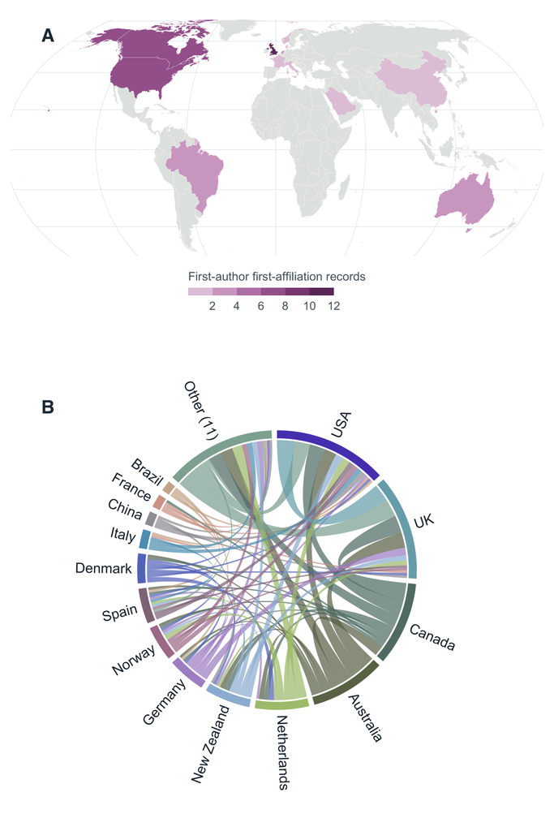

```r
figure_3 <- fig3_panel_a / fig3_panel_b +
  plot_layout(heights = c(0.50, 1)) +
  plot_annotation(
    theme = theme(
      plot.background = element_rect(fill = "transparent", colour = NA),
      plot.margin = margin(8, 8, 8, 8)
    )
  )

export_main_figure(figure_3, 3, "bibliometric_map_chord", 10, 15)

message("network source: ", if (USE_BIBLIOMETRIX) "bibliometrix" else "direct",
        " | records: ", n_records,
        " | first-author countries: ", nrow(first_author_country),
        " | chord sectors: ", length(chord_order),
        " | edges: ", nrow(adjacency))

# For the figure caption: name the countries pooled into the Other sector.
message("\n", other_label, " comprises: ",
        paste(other_countries, collapse = ", "), ".")

figure_3
```

# Figure 4: Policy analysis, alluvial plot top 10

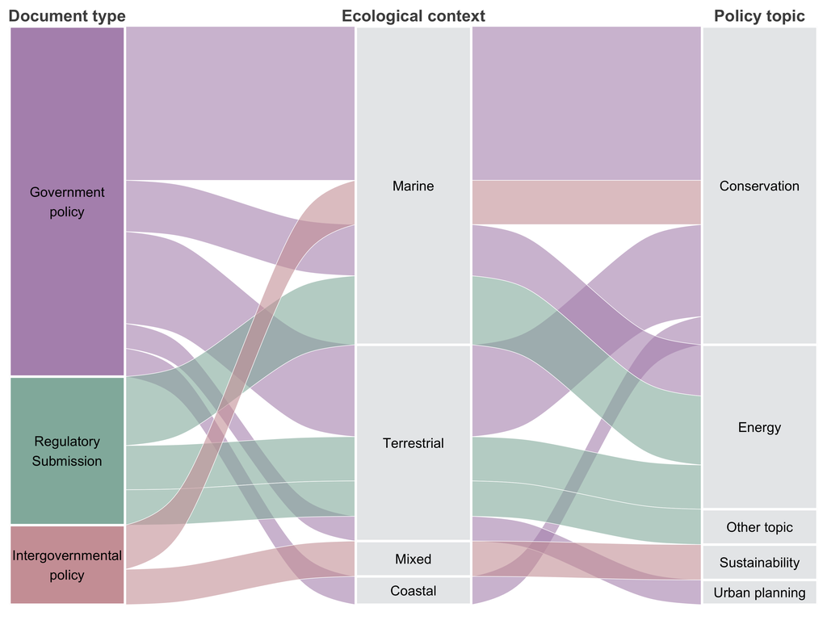

```r
# Call data
dat <- dat_policy |>
  select(policy_topic, ecological_context, policy_document_type)

# Count combinations
dat_alluvial <- dat |>
  group_by(policy_topic, ecological_context, policy_document_type) |>
  summarise(Freq = n(), .groups = "drop")

# ---- Keep the top 10 most common combinations ----
top10_flows <- dat_alluvial |>
  arrange(desc(Freq)) |>
  slice_head(n = 10)

dat_alluvial2 <- dat_alluvial |>
  semi_join(top10_flows,
            by = c("policy_topic", "ecological_context", "policy_document_type")) |>
  mutate(
    policy_topic        = fct_reorder(as.factor(policy_topic), Freq, .fun = sum, .desc = TRUE),
    ecological_context  = fct_reorder(as.factor(ecological_context), Freq, .fun = sum, .desc = TRUE),
    policy_document_type = fct_reorder(as.factor(policy_document_type), Freq, .fun = sum, .desc = TRUE)
  )

# Add line breaks in long labels
dat_alluvial2 <- dat_alluvial2 |>
  mutate(
    policy_document_type = fct_recode(policy_document_type,
      "Government\npolicy"       = "Government policy",
      "Regulatory\nSubmission"   = "Regulatory Submission",
      "Intergovernmental\npolicy" = "Intergovernmental policy"
    )
  )

# Use mauve, teal and rose for the document types.
policy_colours <- c(
  "Government\npolicy"        = "#B393BA",
  "Regulatory\nSubmission"    = "#91B6AA",
  "Intergovernmental\npolicy" = "#CEA0A5"
)
# Plot
figure_4 <- ggplot(dat_alluvial2,
                       aes(axis1 = policy_document_type,
                           axis2 = ecological_context,
                           axis3 = policy_topic,
                           y = Freq)
) +
  # Reorder axes: Document type → Ecological context → Policy topic
  scale_x_discrete(
    limits = c("policy_document_type", "ecological_context", "policy_topic"),
    labels = c("Document type", "Ecological context", "Policy topic"),
    position = "top",
    expand = c(.05, .05)
  ) +
  # Equal widths keep ribbon attachments aligned with every column edge.
  # Thin white outlines distinguish adjacent and crossing ribbons.
  geom_alluvium(aes(fill = policy_document_type),
                width = 1/3, alpha = 0.6, colour = "white", linewidth = 0.25) +
  geom_stratum(aes(fill = after_stat(stratum)),
               width = 1/3, color = "white", linewidth = 1.2) +
  geom_text(stat = "stratum",
            aes(label = after_stat(stratum)),
            size = 5) +
  scale_fill_manual(values = policy_colours, na.value = "#E8E9EB") +
  # Keep the column headings close to the tops of the strata.
  scale_y_continuous(expand = expansion(mult = c(0.01, 0))) +
  theme_minimal(base_size = 14) +
  labs(y = NULL, x = NULL) +
  theme(
    legend.position = "none", # remove legend
    # Axis text
    axis.title.y = element_blank(),
    axis.text.y  = element_blank(),
    axis.ticks.y = element_blank(),
    axis.text.x.top = element_text(face = "bold", size = 17, margin = margin(b = 2)),
    axis.ticks.length.x.top = unit(0, "pt"),

    # Panel and grid tweaks
    panel.grid = element_blank(),   # remove gridlines
    panel.border = element_blank(),
    panel.background = element_rect(fill = "white", colour = NA),

    # Overall text and title
    plot.title = element_text(face = "bold", size = 16, hjust = 0.5),
    plot.subtitle = element_text(size = 12, hjust = 0.5, colour = "grey30"),
    plot.caption = element_text(size = 10, colour = "grey40", hjust = 1),

    # Strata labels spacing
    plot.margin = margin(10, 10, 10, 10)
  )

figure_4
```

```r
export_main_figure(figure_4, 4, "scope_policy_documents_citing_syntheses", 12, 9)
```

# Figure 5: CEESAT scores: CEESAT question scores (all syntheses)

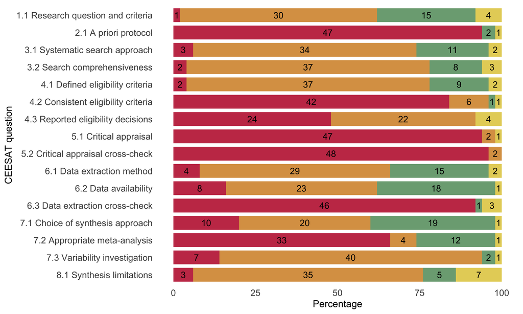

```r
# Labels:
labels <- structure(list(q = c("1.1", "2.1", "3.1", "3.2", "4.1", "4.2",
"4.3", "5.1", "5.2", "6.1", "6.2", "6.3", "7.1", "7.2", "7.3",
"8.1"), label = c("1.1 Research question and criteria",
"2.1 A priori protocol", "3.1 Systematic search approach",
"3.2 Search comprehensiveness", "4.1 Defined eligibility criteria",
"4.2 Consistent eligibility criteria",
"4.3 Reported eligibility decisions", "5.1 Critical appraisal",
"5.2 Critical appraisal cross-check",
"6.1 Data extraction method", "6.2 Data availability",
"6.3 Data extraction cross-check",
"7.1 Choice of synthesis approach", "7.2 Appropriate meta-analysis",
"7.3 Variability investigation",
"8.1 Synthesis limitations"
)), row.names = c(NA, -16L), class = c("tbl_df", "tbl", "data.frame"
))
labels


# Filter and select relevant columns
ceesat_long <- dat_ceesat %>%
  select(starts_with("CEESAT")) %>%
  # Convert columns with "N/A" text to numeric, which creates proper NA values
  mutate(across(c(CEESAT7.2, CEESAT7.3), ~suppressWarnings(as.numeric(.)))) %>%
  pivot_longer(cols = everything(), names_to = "item", values_to = "value") %>%
  group_by(item, value) %>%
  summarise(n = n(), .groups = "drop") %>%
  group_by(item) %>%
  mutate(percent = n / sum(n) * 100)

# Prepare the data for plotting. Here, we join the calculated data with the labels and set up the 'value'
# column as a factor to control the order and appearance in the plot.
ceesat_for_plot <- ceesat_long %>%
  # Create a temporary column 'q' by removing "CEESAT" from the item name
  mutate(q = str_remove(item, "CEESAT")) %>%
  # Join with the labels data frame to get descriptive labels for the plot
  left_join(labels, by = "q") %>%
  # Prepare the 'value' column for plotting
  mutate(
    value = as.character(value),
    # Replace R's NA with a string "NA" for plotting
    value = ifelse(is.na(value), "NA", value),
    # Convert 'value' to a factor to control the stacking order in the legend and bars
    value = factor(value, levels = c("4", "3", "1", "0", "NA"))
  )

# Plot
figure_5 <- ggplot(ceesat_for_plot, aes(x = fct_rev(label), y = percent, fill = value)) +
  geom_col(width = 0.8) +
  geom_text(
    aes(label = n),
    position = position_stack(vjust = 0.5), # Center numbers on each bar segment
    size = 6.5,
    color = "black"
  ) +
  coord_flip() +
  scale_fill_manual(
    name = "Score",
    values = c(
      "0" = "#C73C55",
      "1" = "#DBA053",
      "3" = "#7CA982",
      "4" = "#E6D267"
    ),
    labels = c(
      "NA" = "N/A",
      "0" = "Red",
      "1" = "Amber",
      "3" = "Green",
      "4" = "Gold"
    )
  ) +
  labs(
    x = NULL, # The y-axis labels are self-explanatory
    y = "Percentage",
    fill = "Score"
  ) +
  labs(x = "CEESAT question", y = "Percentage", fill = NULL) +
  theme_minimal(base_size = 20) +
  theme(
    legend.position = "none",        # remove legend
    panel.grid.major = element_blank(),  # remove major grid lines
    panel.grid.minor = element_blank(),  # remove minor grid lines
    axis.ticks = element_blank(),        # remove ticks
    axis.line = element_blank(),          # remove axis lines
    #increase font axis y
    axis.title.y = element_text(size = 20),
    axis.title.x = element_text(size = 20),
    axis.text.y = element_text(size = 18.5), # Increase font size of question labels
    axis.text.x = element_text(size = 18.5)  # Increase font size of percentage labels
     )


figure_5
```

```r
export_main_figure(figure_5, 5, "CEESAT_assessment_syntheses", 15, 9)
```

# Distribution of log-transformed CEESAT scores

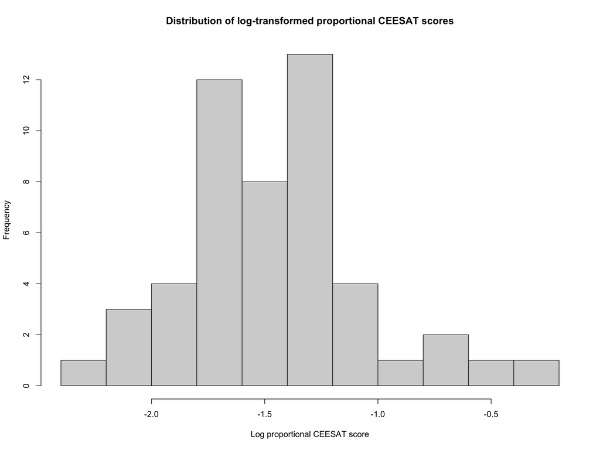

```r
# Use the manuscript's 64-point maximum for all syntheses.
dat <- dat_ceesat %>%
  filter(!is.na(raw_score)) %>%
  mutate(proportional_score = raw_score / 64)
stopifnot(all(dat$proportional_score > 0), all(dat$cited_in_policy %in% c(0, 1)))

# Inspect the distribution of log-transformed scores.
hist(
  log(dat$proportional_score),
  main = "Distribution of log-transformed proportional CEESAT scores",
  xlab = "Log proportional CEESAT score"
)
```

# Welch’s t-test

```r
# Compare log-transformed proportional CEESAT scores between policy-citation groups.
# R uses 0 (not cited) minus 1 (cited) for the difference reported below.
main_analysis <- t.test(
  log(proportional_score) ~ cited_in_policy,
  data = dat
)
```

Welch’s two-sample t-test on log-transformed proportional CEESAT scores

| Result | Value |
| --- | --- |
| Syntheses not cited (n) | 27 |
| Syntheses cited (n) | 23 |
| Mean log score: not cited | -1.4236 |
| Mean log score: cited | -1.5076 |
| Mean difference (not cited minus cited) | 0.0841 |
| 95% confidence interval | -0.1551 to 0.3232 |
| t statistic | 0.7088 |
| Degrees of freedom | 43.0854 |
| Two-sided p value | 0.4823 |

# Figure S3: Synthesis characteristics and content mapping

```r
# Recreate ComplexUpset's default styling with the installed ggplot2 version.
# ComplexUpset 1.3.3 bundles older theme objects that fail with ggplot2 4.x.
s3_upset_themes <- list(
  intersections_matrix = theme_minimal() + theme(
    axis.text.x = element_blank(),
    axis.ticks.x = element_blank(),
    axis.title.y = element_blank()
  ),
  "Intersection size" = theme_minimal() + theme(
    axis.text.x = element_blank(),
    axis.title.x = element_blank()
  ),
  overall_sizes = theme_minimal() + theme(
    axis.title.y = element_blank(),
    axis.text.y = element_blank(),
    axis.ticks.y = element_blank()
  ),
  default = theme_minimal() + theme(
    axis.text.x = element_blank(),
    axis.title.x = element_blank()
  )
)
```

## Panel A: Review type by publication year

```r
review_type_counts <- map %>%
  select(study_id, year, review_type) %>%
  distinct() %>%
  count(year, review_type, name = "paper_count") %>%
  complete(
    year = seq(min(map$year, na.rm = TRUE), max(map$year, na.rm = TRUE)),
    review_type = c("Systematic review", "Meta-analysis", "Systematic map"),
    fill = list(paper_count = 0)
  ) %>%
  mutate(
    review_type = factor(
      review_type,
      levels = c("Systematic review", "Meta-analysis", "Systematic map")
    )
  )

figS3_a <- ggplot(
  review_type_counts,
  aes(x = year, y = paper_count, fill = review_type)
) +
  geom_col(width = 0.7) +
  geom_text(
    data = filter(review_type_counts, paper_count > 0),
    aes(label = paper_count),
    position = position_stack(vjust = 0.5),
    size = 4,
    fontface = "bold"
  ) +
  scale_fill_manual(
    name = NULL,
    values = c(
      "Systematic review" = "#C6C1F0FF",
      "Meta-analysis" = "#F498B6FF",
      "Systematic map" = "#70C1BFFF"
    )
  ) +
  scale_x_continuous(
    breaks = seq(min(review_type_counts$year), max(review_type_counts$year), 1)
  ) +
  scale_y_continuous(limits = c(0, 12), breaks = seq(0, 12, 2)) +
  labs(x = NULL, y = "Number of syntheses", tag = "A") +
  theme_minimal(base_size = 13) +
  theme(
    axis.text.x = element_text(angle = 45, hjust = 1),
    legend.position = "inside",
    legend.position.inside = c(0.18, 0.78),
    panel.grid = element_blank()
  )

# Intermediate panel: figS3_a
```

## Panel B: Environment average per paper

```r
# Average number of environment types per paper

# 1. Process ecosystem categories
env <- map %>%
  select(study_id, ecosystem_type) %>%
  mutate(ecosystem_type = str_split(ecosystem_type, ",\\s*")) %>%
  unnest(ecosystem_type) %>%
  mutate(ecosystem_type = str_trim(ecosystem_type)) %>%
  filter(!is.na(ecosystem_type), ecosystem_type != "") %>%
  distinct(study_id, ecosystem_type)

# 2. Count syntheses per ecosystem category
env_counts <- env %>%
  count(ecosystem_type, name = "paper_count") %>%
  arrange(-paper_count) %>%
  mutate(ecosystem_type = fct_reorder(ecosystem_type, paper_count))

# 3. Calculate automatic label
n_syntheses <- n_distinct(map$study_id)
env_total_assignments <- sum(env_counts$paper_count)
env_mean_categories <- env_total_assignments / n_syntheses

env_label <- paste0(
  "Mean ecosystem categories per synthesis:\n",
  sprintf("%.2f", env_mean_categories),
  " (", env_total_assignments,
  " category assignments\nacross ",
  n_syntheses,
  " syntheses)"
)

# 4. Show summary statistics
env_counts %>%
  mutate(percentage = (paper_count / n_syntheses) * 100) %>%
  print(n = Inf)

# 5. UpSet plot data
dat_upset_env <- env |>
  mutate(value = 1) |>
  pivot_wider(
    id_cols = study_id,
    names_from = ecosystem_type,
    values_from = value,
    values_fill = 0
  )

# 6. Plotting
figS3_b <- upset(
  dat_upset_env,
  themes = s3_upset_themes,
  stripes = upset_stripes(geom = geom_segment(linewidth = 7)),
  intersect = colnames(dat_upset_env)[-1],
  name = "",
  base_annotations = list(
    "Intersection size" = intersection_size(
      mapping = aes(fill = 'bars_color')
    ) +
      annotate(
        geom = "text", x = Inf, y = Inf,
        label = env_label,
        vjust = 1, hjust = 1
      ) +
      ylab("Number of syntheses") +
      scale_fill_manual(
        values = c('bars_color' = '#7370b3'),
        guide = 'none'
      ) +
      scale_y_continuous(
        limits = c(0, 20),
        breaks = seq(0, 20, 4)
      ) +
      labs(tag = "B") +
      theme_minimal(base_size = 14) +
      theme(
        panel.grid.major = element_blank(),
        panel.grid.minor = element_blank(),
        panel.background = element_blank(),
        axis.title.x = element_blank(),
        axis.text.x  = element_blank(),
        axis.ticks.x = element_blank(),
        axis.title.y = element_blank()
      )
  ),
  matrix = intersection_matrix(
    geom = geom_point(shape = 16, size = 1.8)
  ),
  set_sizes = FALSE,
  min_size = 0
)

# Intermediate panel: figS3_b
```

## Panel C: Noise source average per paper

```r
# Average number of noise sources per paper

# 1. Process noise-source categories
noise <- map %>%
  select(study_id, noise_source) %>%
  mutate(noise_source = str_split(noise_source, ",\\s*")) %>%
  unnest(noise_source) %>%
  mutate(noise_source = str_trim(noise_source)) %>%
  filter(!is.na(noise_source), noise_source != "") %>%
  distinct(study_id, noise_source)

# 2. Count syntheses per noise-source category
noise_counts <- noise %>%
  count(noise_source, name = "paper_count") %>%
  arrange(-paper_count) %>%
  mutate(noise_source = fct_reorder(noise_source, paper_count))

# 3. Calculate automatic label
n_syntheses <- n_distinct(map$study_id)

noise_total_assignments <- sum(noise_counts$paper_count)
noise_mean_categories <- noise_total_assignments / n_syntheses

noise_label <- paste0(
  "Mean noise-source categories per synthesis:\n",
  sprintf("%.2f", noise_mean_categories),
  " (", noise_total_assignments,
  " category assignments\nacross ",
  n_syntheses,
  " syntheses)"
)

# 4. Show summary statistics
noise_counts %>%
  mutate(percentage = (paper_count / n_syntheses) * 100) %>%
  print(n = Inf)

# 5. UpSet plot data
dat_upset_noise <- noise |>
  mutate(value = 1) |>
  pivot_wider(
    id_cols = study_id,
    names_from = noise_source,
    values_from = value,
    values_fill = 0
  )

# 6. Plotting
figS3_c <- upset(
  dat_upset_noise,
  themes = s3_upset_themes,
  stripes = upset_stripes(geom = geom_segment(linewidth = 7)),
  intersect = colnames(dat_upset_noise)[-1],
  name = "",
  base_annotations = list(
    "Intersection size" = intersection_size(
      mapping = aes(fill = 'bars_color')
    ) +
      annotate(
        geom = "text", x = Inf, y = Inf,
        label = noise_label,
        vjust = 1, hjust = 1
      ) +
      ylab("Number of syntheses") +
      scale_fill_manual(
        values = c('bars_color' = '#7370b3'),
        guide = 'none'
      ) +
      scale_y_continuous(
        limits = c(0, 8),
        breaks = seq(0, 8, 2)
      ) +
      labs(tag = "C") +
      theme_minimal(base_size = 14) +
      theme(
        panel.grid.major = element_blank(),
        panel.grid.minor = element_blank(),
        panel.background = element_blank(),
        axis.title.x = element_blank(),
        axis.text.x  = element_blank(),
        axis.ticks.x = element_blank(),
        axis.title.y = element_blank()
      )
  ),
  matrix = intersection_matrix(
    geom = geom_point(shape = 16, size = 1.8)
  ),
  set_sizes = FALSE,
  min_size = 0
)

# Intermediate panel: figS3_c
```

## Panel D. Outcome average per paper:

```r
# Average number of outcome categories per paper

# 1. Process outcome categories
outcomes <- map %>%
  select(study_id, outcome_category) %>%
  mutate(outcome_category = str_split(outcome_category, ",\\s*")) %>%
  unnest(outcome_category) %>%
  mutate(outcome_category = str_trim(outcome_category)) %>%
  filter(!is.na(outcome_category), outcome_category != "") %>%
  distinct(study_id, outcome_category)

# 2. Count syntheses per outcome category
outcome_counts <- outcomes %>%
  count(outcome_category, name = "paper_count") %>%
  arrange(-paper_count) %>%
  mutate(outcome_category = fct_reorder(outcome_category, paper_count))

# 3. Calculate automatic label
n_syntheses <- n_distinct(map$study_id)

outcome_total_assignments <- sum(outcome_counts$paper_count)
outcome_mean_categories <- outcome_total_assignments / n_syntheses

outcome_label <- paste0(
  "Mean outcome categories per synthesis:\n",
  sprintf("%.2f", outcome_mean_categories),
  " (", outcome_total_assignments,
  " category assignments\nacross ",
  n_syntheses,
  " syntheses)"
)

# 4. Show summary statistics
outcome_counts %>%
  mutate(percentage = (paper_count / n_syntheses) * 100) %>%
  print(n = Inf)

# 5. UpSet plot data
dat_upset_outcomes <- outcomes |>
  mutate(value = 1) |>
  pivot_wider(
    id_cols = study_id,
    names_from = outcome_category,
    values_from = value,
    values_fill = 0
  )

# 6. Plotting
figS3_d <- upset(
  dat_upset_outcomes,
  themes = s3_upset_themes,
  stripes = upset_stripes(geom = geom_segment(linewidth = 7)),
  intersect = colnames(dat_upset_outcomes)[-1],
  name = "",

  base_annotations = list(
    "Intersection size" = intersection_size(
      mapping = aes(fill = 'bars_color')
    ) +
      annotate(
        geom = "text", x = Inf, y = Inf,
        label = outcome_label,
        vjust = 1, hjust = 1
      ) +
      ylab("Number of syntheses") +
      scale_fill_manual(
        values = c('bars_color' = '#7370b3'),
        guide = 'none'
      ) +
      scale_y_continuous(
        limits = c(0, 10),
        breaks = seq(0, 10, 2)
      ) +
      labs(tag = "D") +
      theme_minimal(base_size = 14) +
      theme(
        panel.grid.major = element_blank(),
        panel.grid.minor = element_blank(),
        panel.background = element_blank(),
        axis.title.x = element_blank(),
        axis.text.x  = element_blank(),
        axis.ticks.x = element_blank(),
        axis.title.y = element_blank()
      )
  ),

  matrix = intersection_matrix(
    geom = geom_point(shape = 16, size = 1.8)
  ),

  set_sizes = FALSE,
  min_size = 0
)

# Intermediate panel: figS3_d
```

## Patchwork plots—Figure S3

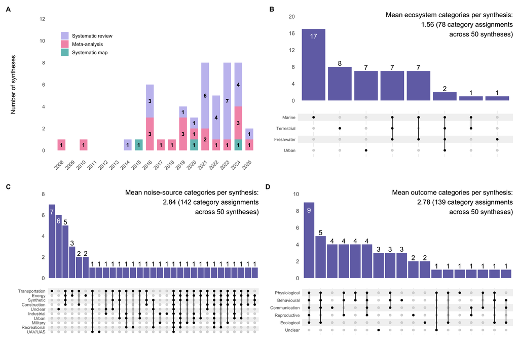

```r
# Create panel pairs for better layout

figS3_ab <- (figS3_a | figS3_b) +
  plot_layout(nrow = 1) &
  theme(plot.tag = element_text(size = 14, face = "bold"))

figS3_cd <- (figS3_c | figS3_d) +
  plot_layout(nrow = 1) &
  theme(plot.tag = element_text(size = 14, face = "bold"))


# Create figure
figure_s3 <- figS3_ab / figS3_cd +
  plot_layout(nrow = 2) &
  theme(plot.tag = element_text(size = 14, face = "bold"))


# Save figure with all panels
figure_s3
```

```r
save_supplementary_figure(here("Figures", "Supplementary", "Figure_S3_synthesis_characteristics.pdf"), figure_s3, width = 15, height = 10, dpi = 300)
save_supplementary_figure(here("Figures", "Supplementary", "Figure_S3_synthesis_characteristics.png"), figure_s3, width = 15, height = 10, dpi = 300)
```

# Figure S4: Keywords

## Panel A: keyword bargraph

```r
# ---- Parameters ----
# Split by semi colon and then calculate frequency
dt.long <- biblio %>%
  select(author_keywords, index_keywords, doi) %>%
  pivot_longer(cols = c("author_keywords", "index_keywords")) %>%
  separate_longer_delim(col = "value",
                        delim = ";")
dt.long

# Keyword synonym dictionary
synonyms <- c(
  # Meta-analysis variants
  "Meta Analysis"     = "Meta-Analysis",
  "Meta Analyses"     = "Meta-Analysis",
  "Literature Review" = "Review",

  # Fish variants
  "Fishes"            = "Fish",
  "Fishing"            = "Fishery",
  "Fish Physiology" = "Fish",
  "Fish Behaviour"    = "Fish",
  "Fishery"           = "Fishery",
  "Fisheries"           = "Fishery",
  "Pisces"            = "Fish",
  "Aquatic Organisms" = "Aquatic Species",
  "Aquatic Species" = "Aquatic Species",

  # Marine environment
  "Marine Soundscape" = "Marine",
  "Marine" = "Marine",
  "Marine Ecosystem" = "Marine Ecosystem",
  "Marine Ecosystems" = "Marine Ecosystem",
  "Marine Environment" = "Marine Ecosystem",
  "Marine Environments" = "Marine Ecosystem",
  # Match the title case applied to keyword input before this dictionary.
  "Marine Vessels" = "Marine Vessel",
  "Marine Vessel" = "Marine Vessel",
  "Vessel" = "Marine Vessel",
  "Vessels" = "Marine Vessel",
  "Ship" = "Marine Vessel",
  "Shipping" = "Marine Vessel",


  # Mammal variants
  "Mammals"           = "Mammal",
  "Mammalia"          = "Mammal",

  # Bird variants
  "Birds"             = "Bird",
  "Aves"              = "Bird",

  # Invertebrate variants
  "Invertebrates"     = "Invertebrate",
  "Invertebrata"      = "Invertebrate",

  # Animal variants
  "Animal"            = "Animals",
  "Fauna"            = "Animals",
  "Animalia"          = "Animals",
  "Wild Animal"       = "Wildlife",
  "Animals, Wild"     = "Wildlife",
  "Behavior, Animal"     = "Behaviour",
  "Behaviour, Animal"     = "Behaviour",
  "Behavioural"     = "Behaviour",
  "Behavior"  = "Behaviour",
  "Behavioral"  = "Behaviour",


  # Human variants
  "Humans"            = "Human",

  # Cetacean variants
  "Cetacea"           = "Cetaceans",
  "Cetacean"          = "Cetaceans",

  # Whale variants
  "Whales"            = "Whale",
  "Beluga Whales"     = "Beluga Whale",
  "Bowhead Whales"    = "Bowhead Whale",

  # Dolphin variants
  "Dolphins"          = "Dolphin",

  # Noise variants
  "Noise Impact"      = "Noise",
  "Noise-Induced Stress" = "Stress",

  # Anthropogenic noise variants
  "Anthrophony"       = "Anthropophony",
  "Anthropogenic Sounds" = "Anthropogenic Sound",
  "Anthropogenic Pollutants" = "Anthropogenic Pollutant",
  "Human-Induced Environmental Change" = "Human Disturbance",
  "Human Disturbances" = "Human Disturbance",
  "Human Disturbance" = "Human Disturbance",
  "Human Activities" = "Human Activity",
  "Human Activity" = "Human Activity",


  # Pollution variants
  "Sound Pollution"   = "Noise Pollution",
  "Acoustic Pollution"= "Noise Pollution",
  "Contaminación Por Ruido" = "Noise Pollution",
  "Contaminación Sonora"    = "Noise Pollution",
  "声污染"                 = "Noise Pollution",
  "噪音污染"                = "Noise Pollution",

  # Urbanization variants
  "Urbanización"      = "Urbanization",
  "城市化"              = "Urbanization",

  # Vertebrate variants
  "Vertebrates"       = "Vertebrate",
  "Vertebrata"        = "Vertebrate",

  # Review variants
  "Systematic Maps"   = "Systematic Map",
  "Systematic Literature Review" = "Systematic Review",
  "Scoping Review"    = "Scoping Review",
  "Review"            = "Review",

  # Risk variants
  "Risks Assessments" = "Risk Assessment",
  "Risk Evaluation"   = "Risk Assessment",
  # Environmental variants
  "Ecosystems" = "Ecosystem",
  "Ecosystem" = "Ecosystem",
  "Environmental" = "Environment",
  "Environment" = "Environment",
  "Environmental Impacts" = "Environmental Impact",
  "Environmental Impact" = "Environmental Impact",
  "Environmental Disturbance" = "Environmental Impact",
  "Environmental Change" = "Environmental Impact",
  "Environmental Effect" = "Environmental Impact",
  "Environmental Fate" = "Environmental Impact",
  "Environmental Stressors" = "Environmental Stress",
  "Environmental Stress" = "Environmental Stress",
  "Environmental Impact Analysis" = "Environmental Impact Assessment",
  "Environmental Impacts Analysis" = "Environmental Impact Assessment",
  "Environmental Impact Assessments" = "Environmental Impact Assessment",
  "Environmental Policies" = "Environmental Policy",
  "Environmental Policy" = "Environmental Policy",
  "Conservation" = "Conservation",
  "Conservation Management" = "Conservation"

)

# ----Standardize case, trim whitespace ----
dt.long <- dt.long %>%
  mutate(value = str_to_title(value)) %>%
  mutate(value = trimws(value)) %>%
# Apply synonyms dictionary
  mutate(value = recode(value, !!!synonyms)) %>%
# drop NA
  filter(!is.na(value) & value != "")

# calculate number of mentions of each keyword—frequencies
keyword.freq <- dt.long %>%
  group_by(value) %>%
  summarize(n = n()) %>%
  arrange(desc(n))

#-------Diagnostics-------
## number of mentions, including repeats
  nrow(dt.long)
## number of unique keywords after grouping
  nrow(keyword.freq)
## unique keyword count
  length(unique(dt.long$value))


keyword.freq <- keyword.freq %>%
  arrange(-n)

# Clean NA
keyword.freq_clean <- keyword.freq %>%
  filter(!is.na(value))

# Reorder factor levels based on frequency for plotting
keyword.freq$value <- factor(keyword.freq$value,
                             levels = rev(keyword.freq$value))

# Plot
figS4_a <- ggplot(data = keyword.freq[1:20, ],
                    aes(x = n, y = value, fill = n))+
  geom_col()+
  scale_fill_gradient(low = "#B4D8E4", high = "#00425E")+
  xlab("Number of keywords")+
  ylab("Keyword")+
  theme_minimal(base_size = 14) +
      theme(
        panel.grid.major = element_blank(),
        panel.grid.minor = element_blank(),
        panel.background = element_blank(),
        axis.title.y = element_blank(),   # Hide the y-axis title
        axis.ticks.x = element_blank()
      )

# Intermediate panel: figS4_a
#Save
```

## Assemble Figure S4

Figure S4 includes a saved word-cloud image and its keyword frequencies. If you change the keywords, update both the image and the frequency table. The code checks that the frequencies match before assembling the figure.

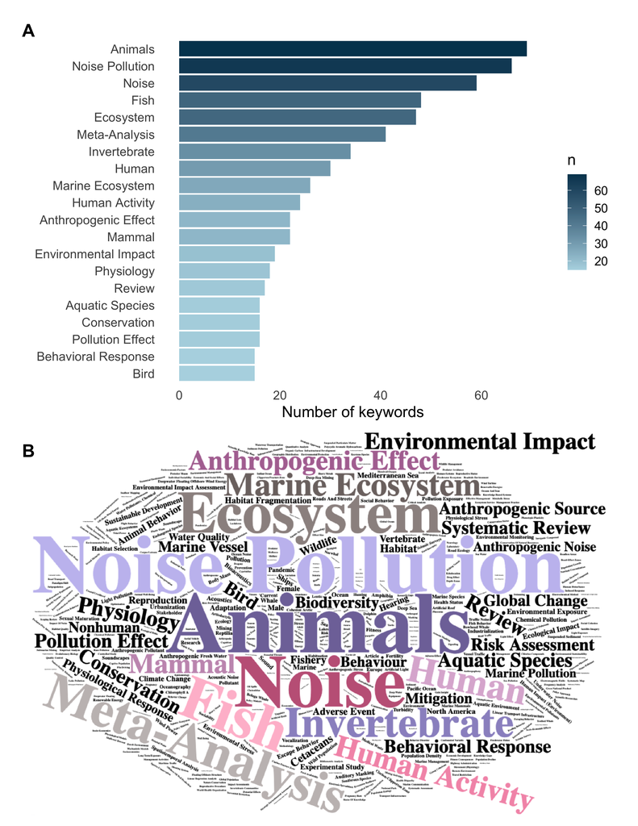

```r
if (!file.exists(cloud_file) || !file.exists(cloud_counts_file)) {
  stop("Export figS4_b and its keyword.freq table before assembling Figure S4.")
}
cloud_counts <- read_csv(cloud_counts_file, show_col_types = FALSE)
current_counts <- keyword.freq %>% mutate(value = as.character(value))
if (!isTRUE(all.equal(as.data.frame(cloud_counts), as.data.frame(current_counts)))) {
  stop("S4 word-cloud frequencies changed. Re-export figS4_b and its frequency CSV.")
}
cloud_panel <- patchwork::wrap_elements(full = grid::rasterGrob(
  png::readPNG(cloud_file), interpolate = FALSE
))
figS4 <- (figS4_a / cloud_panel) +
  plot_layout(heights = c(1, 1)) + plot_annotation(tag_levels = "A") &
  theme(plot.tag = element_text(face = "bold", size = 16),
        plot.margin = margin(10, 10, 10, 10))
save_supplementary_figure(here("Figures", "Supplementary", "Figure_S4_keywords.png"), figS4,
       width = 8, height = 10.35, dpi = 300, bg = "white")
save_supplementary_figure(here("Figures", "Supplementary", "Figure_S4_keywords.pdf"), figS4,
       width = 8, height = 10.35, bg = "white")
figS4
```

```r
unlink(c(cloud_file, cloud_counts_file))
```

# Figure S5: Academic citation count and the three most cited syntheses

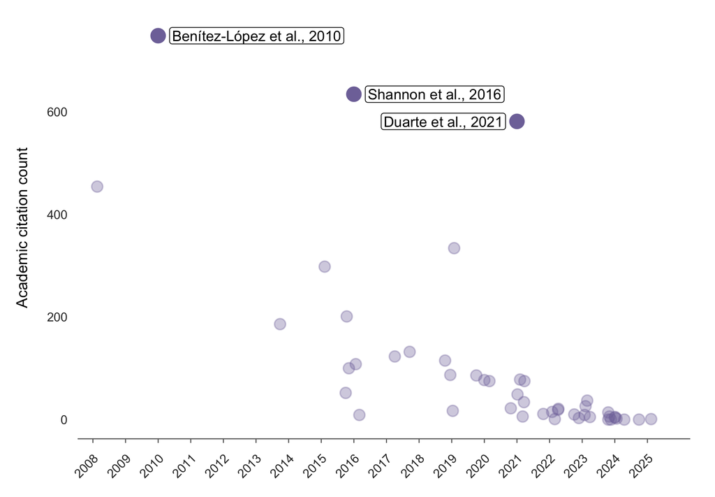

```r
# 1. Create empty label column
biblio$label <- NA

# 2. Assign labels to the three top-cited papers
biblio$label[grepl("Benítez-López", biblio$authors) & biblio$year == 2010] <- "Benítez-López et al., 2010"
biblio$label[grepl("Shannon",       biblio$authors) & biblio$year == 2016] <- "Shannon et al., 2016"
biblio$label[grepl("Duarte",        biblio$authors) & biblio$year == 2021] <- "Duarte et al., 2021"

# Draw each study once. Only unlabelled studies are jittered; highlighted
# points and their labels share the exact publication year and citation count.
figS5 <- ggplot(biblio, aes(x = year, y = cited_by)) +
  geom_point(data = subset(biblio, is.na(label)),
             position = position_jitter(width = 0.3, height = 0, seed = 20261009),
             size = 3.3, alpha = 0.35, color = "#8074A8FF") +
  geom_point(data = subset(biblio, !is.na(label)),
             aes(x = year, y = cited_by),
             color = "#8074A8FF", size = 4.3) +
  geom_label(data = subset(biblio, !is.na(label)),
             # Place the rightmost highlighted study's label to its left.
             aes(label = label,
                 x = year + if_else(grepl("^Duarte", label), -0.35, 0.35),
                 hjust = if_else(grepl("^Duarte", label), 1, 0)),
             vjust = 0.5, size = 10.5 / .pt,
             label.padding = unit(0.15, "lines"), linewidth = 0.25,
             fill = "white", color = "black"
  ) +
   labs(
     x = NULL,
    y = "Academic citation count"#,
  ) +
  scale_x_continuous(breaks = seq(from = min(biblio$year),
                                  to = max(biblio$year), by = 1),
                     expand = expansion(add = c(0.6, 1.2))
                     )+
  theme_minimal(base_size = 16) +
  theme(axis.text.x = element_text(angle = 45, hjust = 1, size = 9, colour = "#333333"),
    axis.text.y = element_text(size = 9, colour = "#333333"),
    axis.title.y = element_text(size = 11, margin = margin(r = 12)),
    axis.line.x = element_line(colour = "#666666", linewidth = 0.35),
    axis.ticks.x = element_line(colour = "#666666", linewidth = 0.35),
    axis.ticks.length.x = unit(3, "pt"),
    panel.grid = element_blank(),
    plot.margin = margin(12, 18, 12, 12)

  )


# 4. Print plot
figS5
```

```r
#Save
# Use the same physical size in PDF and PNG, close to the inserted Word size.
save_supplementary_figure(here("Figures", "Supplementary", "Figure_S5_academic_citation_count.pdf"), figS5, width = 7.2, height = 5, bg = "white")
save_supplementary_figure(here("Figures", "Supplementary", "Figure_S5_academic_citation_count.png"), figS5, width = 7.2, height = 5, dpi = 300, bg = "white")
```

# Figure S6: Policy analysis, alluvial plot all variables

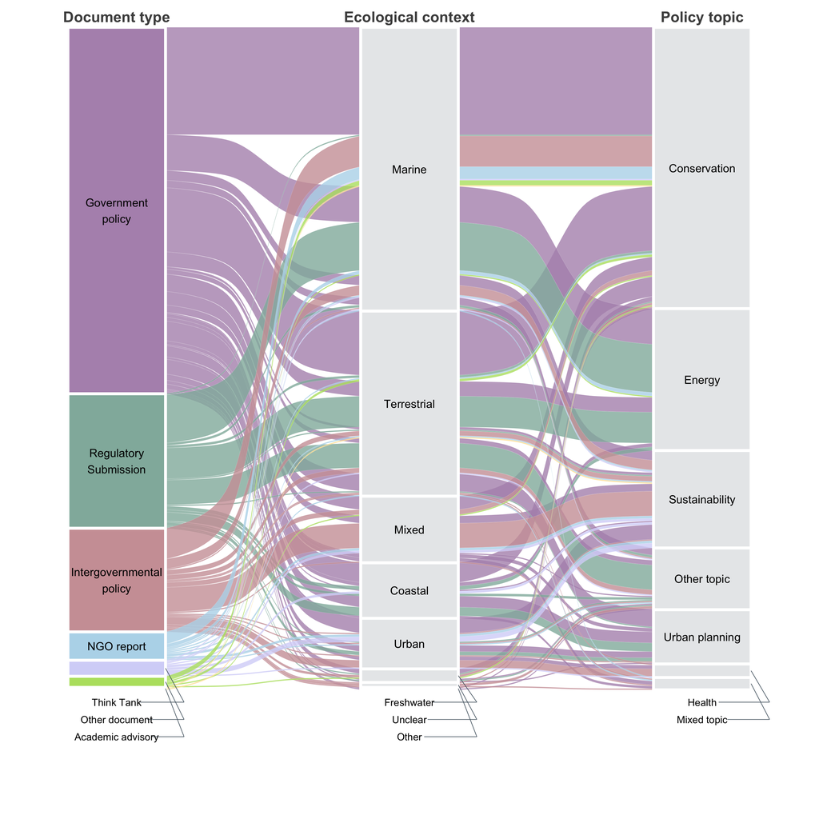

```r
# Alluvial plot with shared Figure 4 colours by document type ----
dat <- dat_policy |>
  select(policy_topic, ecological_context, policy_document_type)

dat_alluvial <- dat |>
  group_by(policy_topic, ecological_context, policy_document_type) |>
  summarise(Freq = n(), .groups = "drop")

# Prefix axis labels for uniqueness and reorder by frequency
dat_alluvial2 <- dat_alluvial |>
  mutate(
    policy_topic        = fct_reorder(as.factor(policy_topic), Freq, .fun = sum, .desc = TRUE),
    ecological_context  = fct_reorder(as.factor(ecological_context), Freq, .fun = sum, .desc = TRUE),
    policy_document_type = fct_reorder(as.factor(policy_document_type), Freq, .fun = sum, .desc = TRUE)
  ) |>
  # Wrap long document-type labels.
  mutate(
    policy_document_type = fct_relabel(policy_document_type, ~ str_replace_all(.x,
                                                                      c("Government policy"        = "Government\npolicy",
                                                                        "Regulatory Submission"    = "Regulatory\nSubmission",
                                                                        "Intergovernmental policy" = "Intergovernmental\npolicy")))
  )


# Match Figure 4 for the shared document types; retain the additional category colours.
policy_colours <- c(
  "Government\npolicy"        = "#B393BA",
  "Regulatory\nSubmission"    = "#91B6AA",
  "Intergovernmental\npolicy" = "#CEA0A5",
  "NGO report"                = "#B7D9EB",
  "Think Tank"                = "#D6D6F8",
  "Academic advisory"        = "#FFE3A3",
  "Other document"           = "#B6E06E"
)

# ---- Plot ----
figS6 <- ggplot(dat_alluvial2,
                       aes(axis1 = policy_document_type,
                           axis2 = ecological_context,
                           axis3 = policy_topic,
                           y = Freq)
) +
  scale_x_discrete(
    limits = c("policy_document_type", "ecological_context", "policy_topic"),
    labels = c("Document type", "Ecological context", "Policy topic"),
    position = "top",
    expand = c(.12, .12)
  ) +
 # Match ribbon and column widths so every attachment is visible.
  geom_alluvium(aes(fill = policy_document_type),
                width = 1/3, alpha = 0.8, knot.pos = 0.4,
                colour = "white", linewidth = 1/35) +
  geom_stratum(aes(fill = after_stat(stratum)),
               color = "white", linewidth = 1.2, width = 1/3) +
  geom_text(stat = "stratum",
            aes(label = ifelse(after_stat(count) >= 18, as.character(after_stat(stratum)), "")),
            size = 3.5) +
  scale_fill_manual(values = policy_colours, na.value = "#E8E9EB") +
  # Keep the column headings close to the tops of the strata.
  scale_y_continuous(expand = expansion(mult = c(0.10, 0))) +

  theme_minimal(base_size = 14) +
  labs(y = "Count of papers", x = NULL) +
  theme(
    legend.position = "none",
    axis.title.y = element_blank(),
    axis.text.y  = element_blank(),
    axis.ticks.y = element_blank(),
    axis.text.x.top = element_text(face = "bold", size = 13, margin = margin(b = 2)),
    axis.ticks.length.x.top = unit(0, "pt"),
    panel.grid = element_blank(),
    panel.border = element_blank(),
    panel.background = element_rect(fill = "white", colour = NA),
    plot.margin = margin(10, 10, 10, 10)
  )


# Move labels for very small strata into the bottom margin, with leader lines.
# These are annotations only: the ribbon and stratum heights remain unchanged.
s6_strata <- ggplot_build(figS6)$data[[2]]
s6_small_labels <- s6_strata |>
  filter(count < 18) |>
  group_by(x) |>
  arrange(desc(y), .by_group = TRUE) |>
  mutate(label_y = -10 - 14 * (row_number() - 1)) |>
  ungroup()
figS6 <- figS6 +
  geom_segment(data = s6_small_labels,
               aes(x = x + 1/6, xend = x + 0.23, y = y, yend = label_y),
               inherit.aes = FALSE, colour = "#52636F", linewidth = 0.25) +
  geom_segment(data = s6_small_labels,
               aes(x = x + 0.23, xend = x + nchar(as.character(stratum)) * 0.006 + 0.02, y = label_y, yend = label_y),
               inherit.aes = FALSE, colour = "#52636F", linewidth = 0.25) +
  geom_text(data = s6_small_labels,
            aes(x = x, y = label_y, label = stratum),
            inherit.aes = FALSE, size = 3.1)
figS6
```

```r
save_supplementary_figure(here("Figures", "Supplementary", "Figure_S6_alluvialplot.pdf"), figS6, width = 10, height = 10, bg = "white")
save_supplementary_figure(here("Figures", "Supplementary", "Figure_S6_alluvialplot.png"), figS6, width = 10, height = 10, dpi = 300, bg = "white")
```

# Figure S7: Policy-citation counts by synthesis publication year

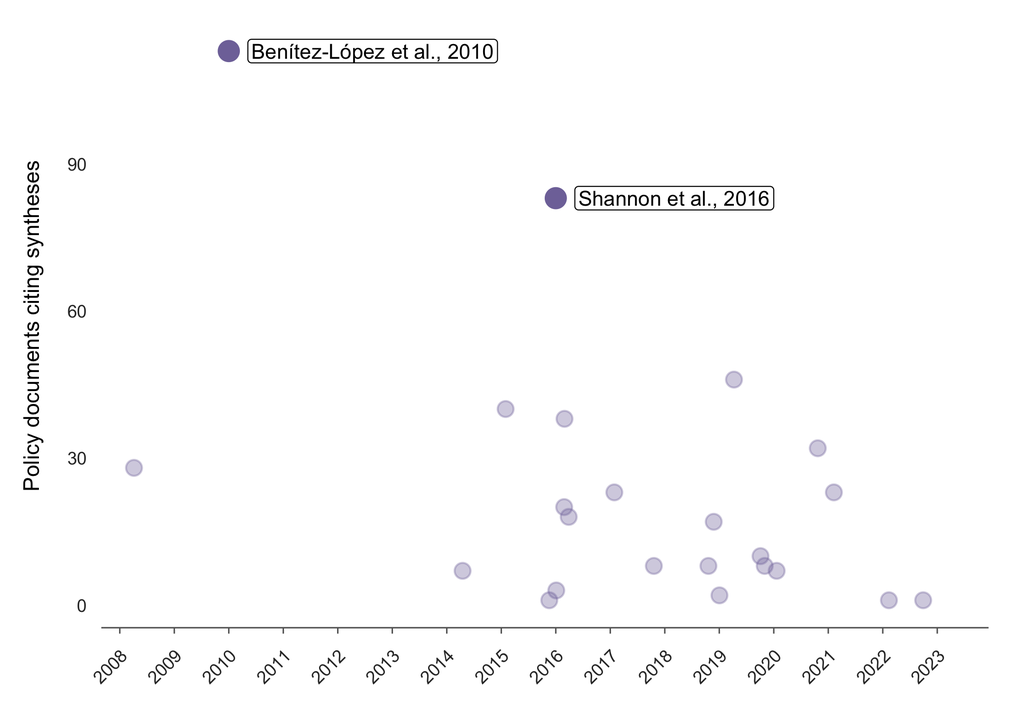

```r
# filter by policy cited or not
pol_fil <- pol_ci %>%
  filter(policy_cited == "Yes")

colnames(pol_fil)

# 3. Create empty label column
pol_cit <- pol_fil %>%
  mutate(label = case_when(
    study_id == "benitez_2010" ~ "Benítez-López et al., 2010",
    study_id == "shannon_2016" ~ "Shannon et al., 2016",
    TRUE ~ NA_character_
  ))


# Draw each study once, with labels aligned to the unjittered highlighted points.
figS7 <- ggplot(pol_cit, aes(x = year, y = unique_policy_citations)) +
  geom_point(data = subset(pol_cit, is.na(label)),
             position = position_jitter(width = 0.3, height = 0, seed = 20261009),
             size = 3.3, alpha = 0.35, color = "#8074A8FF") +
  geom_point(data = subset(pol_cit, !is.na(label)),
             aes(x = year, y = unique_policy_citations),
             color = "#8074A8FF", size = 4.3) +
  geom_label(data = subset(pol_cit, !is.na(label)),
             aes(label = label),
             nudge_x = 0.35, hjust = 0, vjust = 0.5, size = 10.5 / .pt,
             label.padding = unit(0.15, "lines"), linewidth = 0.25,
             fill = "white", color = "black"
  ) +
   labs(
     x = NULL,
    y = "Policy documents citing syntheses"#,
  ) +
  scale_x_continuous(breaks = seq(from = min(pol_cit$year),
                                  to = max(pol_cit$year), by = 1),
                     expand = expansion(add = c(0.6, 1.2))
                     )+
  theme_minimal(base_size = 16) +
  theme(axis.text.x = element_text(angle = 45, hjust = 1, size = 9, colour = "#333333"),
    axis.text.y = element_text(size = 9, colour = "#333333"),
    axis.title.y = element_text(size = 11, margin = margin(r = 12)),
    axis.line.x = element_line(colour = "#666666", linewidth = 0.35),
    axis.ticks.x = element_line(colour = "#666666", linewidth = 0.35),
    axis.ticks.length.x = unit(3, "pt"),
    panel.grid = element_blank(),
    plot.margin = margin(12, 18, 12, 12)

  )


# 5. Print plot
figS7
```

```r
#Save
save_supplementary_figure(here("Figures", "Supplementary", "Figure_S7_policyciting.pdf"), figS7, width = 7.2, height = 5, bg = "white")
save_supplementary_figure(here("Figures", "Supplementary", "Figure_S7_policyciting.png"), figS7, width = 7.2, height = 5, dpi = 300, bg = "white")
```

# Figure S8: Policy trends

We count the policy-citation records in Dataset 3 by policy publication year. Each row contributes once to each panel. We keep repeated entries because they may refer to different chapters or citations in a compilation. These counts represent citation records, rather than unique documents across syntheses.

## Panel A: Policy topic trends

```r
# Retain every source record; totals are identical across the three panels.
annual_policy_records <- dat_policy %>% count(policy_year, name = "n")

# Summarise policy topics
policytopic <- dat_policy %>%
  filter(!is.na(policy_topic)) %>%
  mutate(policy_topic = str_trim(policy_topic)) %>%
  filter(policy_topic != "") %>%
  count(policy_year, policy_topic, name = "n")

# Plot annual citation records by category
figS8_a <- ggplot(policytopic, aes(
  x = policy_year,
  y    = n,
  fill = policy_topic
)) +
  geom_col(width = 0.7) +
  geom_text(
    data = annual_policy_records,
    aes(x = policy_year, y = n, label = n), inherit.aes = FALSE,
    vjust = -0.5, size = 3.5, colour = "#222222"
  ) +
   scale_fill_paletteer_d(
  "ggthemes::Purple_Pink_Gray",
  name = "Policy topic trends",
  guide = guide_legend(
    override.aes = list(
      shape = 21,
      size = 4,
      color = NA
    )
  )
  ) +
  labs(
     x = NULL,
    y = "Policy citation records"
  ) +
  scale_x_continuous(breaks = seq(from = min(policytopic$policy_year),
                                  to = max(policytopic$policy_year), by = 1)
                     )+
  theme_minimal(base_size = 13) +
  theme(axis.text.x = element_text(angle = 45, hjust = 1),
    legend.position = "inside",
    legend.position.inside = c(.15, .65),
    legend.text = element_text(size = 9),
    legend.title = element_blank(),
    panel.grid = element_blank()

  )
# Intermediate panel: figS8_a
```

## Panel B: Policy ecological context trends

```r
# Step 1: Read data and process outcomes

policy_eco <- dat_policy %>%
  filter(!is.na(ecological_context)) %>%
  mutate(ecological_context = str_trim(ecological_context)) %>%
  filter(ecological_context != "") %>%
  count(policy_year, ecological_context, name = "n")

# Plot annual citation records by category
figS8_b <- ggplot(policy_eco, aes(
  x    = policy_year,
  y    = n,
  fill = ecological_context
)) +
  geom_col(width = 0.7) +
  geom_text(
    data = annual_policy_records,
    aes(x = policy_year, y = n, label = n), inherit.aes = FALSE,
    vjust = -0.5, size = 3.5, colour = "#222222"
  ) +
   scale_fill_paletteer_d(
  "ggthemes::Purple_Pink_Gray",
  name = "Policy ecosystem trends",
  guide = guide_legend(
    override.aes = list(
      shape = 21,
      size = 4,
      color = NA
    )
  )
  ) +
  labs(
     x = NULL,
    y = "Policy citation records"
  ) +
  scale_x_continuous(breaks = seq(from = min(policy_eco$policy_year),
                                  to = max(policy_eco$policy_year), by = 1)
                     )+
  theme_minimal(base_size = 13) +
  theme(axis.text.x = element_text(angle = 45, hjust = 1),
    legend.position = "inside",
    legend.position.inside = c(.15, .65),
    legend.text = element_text(size = 9),
    legend.title = element_blank(),
    panel.grid = element_blank()

  )

# Intermediate panel: figS8_b
```

## Panel C: Policy document type trends

```r
# Manage data
policytype <- dat_policy %>%
  filter(!is.na(policy_document_type)) %>%
  mutate(policy_document_type = str_trim(policy_document_type)) %>%
  filter(policy_document_type != "") %>%
  count(policy_year, policy_document_type, name = "n")


# Plot annual citation records by category
figS8_c <- ggplot(policytype, aes(
  x    = policy_year,
  y    = n,
  fill = policy_document_type
)) +
  geom_col(width = 0.7) +
  geom_text(
    data = annual_policy_records,
    aes(x = policy_year, y = n, label = n), inherit.aes = FALSE,
    vjust = -0.5, size = 3.5, colour = "#222222"
  ) +
   scale_fill_paletteer_d(
  "ggthemes::Purple_Pink_Gray",
  name = "Policy document type trends",
  guide = guide_legend(
    override.aes = list(
      shape = 21,
      size = 4,
      color = NA
    )
  )
  ) +
  labs(
     x = "Policy publication year",
    y = "Policy citation records"
  ) +
  scale_x_continuous(breaks = seq(from = min(policytype$policy_year),
                                  to = max(policytype$policy_year), by = 1)
                     )+
  theme_minimal(base_size = 13) +
  theme(axis.text.x = element_text(angle = 45, hjust = 1),
    legend.position = "inside",
    legend.position.inside = c(.15, .65),
    legend.text = element_text(size = 9),
    legend.title = element_blank(),
    panel.grid = element_blank()

  )

# Intermediate panel: figS8_c
```

## Assemble Figure S8

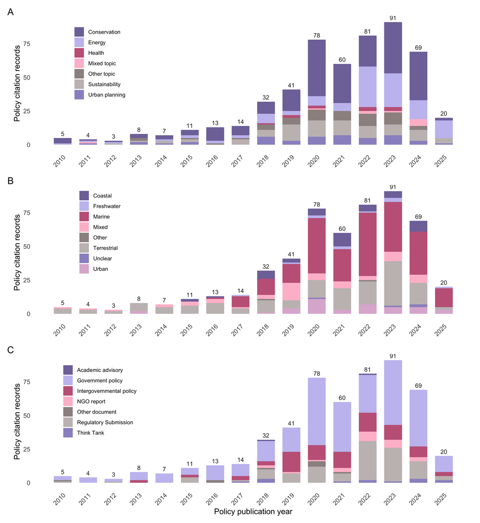

```r
# Each record must contribute once to all three panels.
annual_records <- dat_policy %>% count(policy_year, name = "n") %>% arrange(policy_year)
for (panel_data in list(policytopic, policy_eco, policytype)) {
  annual_panel <- panel_data %>% group_by(policy_year) %>%
    summarise(n = sum(n), .groups = "drop") %>% arrange(policy_year)
  stopifnot(sum(panel_data$n) == nrow(dat_policy),
            isTRUE(all.equal(as.data.frame(annual_panel), as.data.frame(annual_records))))
}
# Combine the panels to create the figure
figS8 <- figS8_a + figS8_b + figS8_c + plot_layout(nrow = 3) + plot_annotation(tag_levels = "A")

#Show figure
figS8
```

```r
# Save figure
save_supplementary_figure(here("Figures", "Supplementary", "Figure_S8_trends.pdf"), plot = figS8, bg = "white", width = 11, height = 12, dpi = 300)
save_supplementary_figure(here("Figures", "Supplementary", "Figure_S8_trends.png"), plot = figS8, bg = "white", width = 11, height = 12, dpi = 300)
```

# Figure S9: Annual trends in syntheses cited and not cited in policy

```r
# Tidy data
tidy_trends <- map %>%
  select(study_id, year, cited_policy, outcome_category, noise_source, ecosystem_type) %>%
  pivot_longer(
    cols = c(outcome_category, noise_source, ecosystem_type),
    names_to = "category_group",
    values_to = "category_value"
  ) %>%
  filter(!is.na(category_value), category_value != "") %>%
  separate_rows(category_value, sep = "[,;]\\s*") %>%
  mutate(category_value = str_trim(category_value)) %>%

# Remove missing category values.
  filter(category_value != "NA") %>%
 # Selecting columns to plot
  group_by(year, cited_policy, category_group, category_value) %>%
  summarise(n = n_distinct(study_id), .groups = "drop")

# Creating a plotting function
create_trend_plot <- function(df, legend_title, plot_title = NULL) {

  ggplot(df, aes(x = year, y = n, fill = category_value)) +
    geom_col(width = 0.8, position = position_stack()) +

    # Count for each segment inside the bar
    geom_text(
      aes(label = n),
      position = position_stack(vjust = 0.5),
      size = 5,
      colour = "white",
      fontface = "bold"
    ) +

    scale_fill_paletteer_d("ggthemes::Purple_Pink_Gray", name = legend_title) +
    scale_x_continuous(
      breaks = seq(2008, 2025, 1),
      # Include the full width of the first and last bars (width = 0.8).
      limits = c(2007.5, 2025.5)
    ) +
    scale_y_continuous(
      limits = c(0, 30),
      breaks = seq(0, 30, 5)
  )+
    labs(
      title = plot_title, # Title will be applied only if provided
      x = NULL,
      y = "Number of syntheses"
    ) +
    theme_minimal(base_size = 12) +
    theme(
      panel.grid = element_blank(),
      axis.text.x = element_text(angle = 45, hjust = 1, size = 16),
      legend.title = element_blank (),
      legend.text = element_text(size = 12),
      plot.title = element_text(face = "bold", size = 16, hjust = 0.5), # Larger title
      legend.position ="inside", legend.position.inside = c(.15, .65),
      axis.title.y = element_text(size = 18),
      axis.text.y = element_text(size = 18),
      axis.title.x = element_text(size = 18)
    )
}
```

## Panel A: Outcome category

```r
# Create individual plots for each combination of category_group and cited_policy, adjust theme individually

# Outcome category cited and not cited in policy
p_A <- tidy_trends %>%
  filter(category_group == "outcome_category", cited_policy == "no") %>%
  create_trend_plot(legend_title = "Outcome", plot_title = "Not Cited in Policy") +
  labs(tag = "A") +
  theme (plot.tag = element_text(size = 20))


p_B <- tidy_trends %>%
  filter(category_group == "outcome_category", cited_policy == "yes") %>%
  create_trend_plot(legend_title = "Outcome", plot_title = "Cited in Policy") +
  theme(legend.position = "none",
        axis.title.y = element_blank())

# See plots
```

## Panel B: Noise source

```r
# Noise source cited and not cited in policy
p_C <- tidy_trends %>%
  filter(category_group == "noise_source", cited_policy == "no") %>%
  create_trend_plot(legend_title = "Noise Source") +
  labs(tag = "B") +
  theme (plot.tag = element_text(size = 20))


p_D <- tidy_trends %>%
  filter(category_group == "noise_source", cited_policy == "yes") %>%
  create_trend_plot(legend_title = "Noise Source") +
   theme(legend.position = "none",
        axis.title.y = element_blank())

# See plots
```

## Panel C: Ecosystem type

```r
# Ecosystem type cited and not cited in policy
p_E <- tidy_trends %>%
  filter(category_group == "ecosystem_type", cited_policy == "no") %>%
  create_trend_plot(legend_title = "Environment")+
  labs(tag = "C") +
  theme(axis.title.x = element_text(size = 18),
        plot.tag = element_text(size = 20))


p_F <- tidy_trends %>%
  filter(category_group == "ecosystem_type", cited_policy == "yes") %>%
  create_trend_plot(legend_title = "Environment") +
  theme(legend.position = "none",
        axis.title.y = element_blank(),
        axis.title.x = element_text(size = 18))

# See plots
```

## Patchwork Figure S9: Assemble the final figure

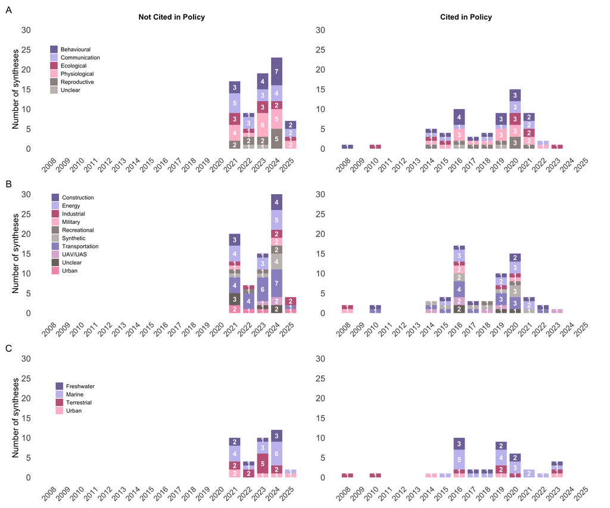

```r
# Assembling sub-figures in pairs for better alignment

figS9_a <- (p_A + p_B) +
  plot_layout(ncol = 2)

figS9_b <- (p_C + p_D) +
  plot_layout(ncol = 2)

figS9_c <- (p_E + p_F) +
  plot_layout(ncol = 2)

# Combining three rows for final figure

figS9 <- (figS9_a / figS9_b / figS9_c)

# Show final figure
figS9
```

```r
# To save the figure
save_supplementary_figure(here("Figures", "Supplementary", "Figure_S9_trends_syntheses_cited_not_cited.pdf"), figS9, width = 18, height = 15, dpi = 300)
save_supplementary_figure(here("Figures", "Supplementary", "Figure_S9_trends_syntheses_cited_not_cited.png"), figS9, width = 18, height = 15, dpi = 300)
```

# Figure S10: Geographical distribution of policy citation records

We count policy-citation records by their recorded publication location. For this figure, we group Nairobi under Kenya and UK constituent countries under the United Kingdom. This describes publication location, not policy scope. We show European Union, International and Mixed separately from countries.

## Panel A: Publication countries

```r
policy_location_data <- dat_policy %>%
  mutate(policy_country_clean = case_when(
    str_trim(policy_country) %in% c("Northern Ireland", "Scotland", "United Kingdom") ~ "United Kingdom",
    str_trim(policy_country) %in% c("USA", "U.S.A.", "United States") ~ "United States of America",
    # UNEP's GEO-6 publication location is Nairobi, Kenya (Dataset3 row 290).
    str_trim(policy_country) == "Nairobi" ~ "Kenya",
    TRUE ~ str_trim(policy_country)
  ))
stopifnot(!anyNA(policy_location_data$policy_country_clean),
          all(nzchar(policy_location_data$policy_country_clean)))
policy_counts <- policy_location_data %>%
  count(policy_country_clean, name = "n", sort = TRUE)
non_country_labels <- c("International", "European Union", "Mixed")
non_country_counts <- policy_counts %>%
  filter(policy_country_clean %in% non_country_labels)
country_specific_counts <- policy_counts %>%
  filter(!policy_country_clean %in% non_country_labels)

world <- ne_countries(scale = "medium", returnclass = "sf")
unmatched_countries <- country_specific_counts %>%
  anti_join(sf::st_drop_geometry(world), by = c("policy_country_clean" = "name"))
if (nrow(unmatched_countries)) {
  stop("Unmatched S10 publication countries: ",
       paste(unmatched_countries$policy_country_clean, collapse = ", "))
}
stopifnot(sum(country_specific_counts$n) + sum(non_country_counts$n) == nrow(dat_policy))
map_data <- world %>%
  left_join(country_specific_counts, by = c("name" = "policy_country_clean"))
non_country_note <- non_country_counts %>%
  arrange(match(policy_country_clean, non_country_labels)) %>%
  transmute(label = paste0(policy_country_clean, " (", n, ")")) %>%
  pull(label) %>% paste(collapse = "; ")

figS10_a <- ggplot(map_data) +
  geom_sf(aes(fill = n), colour = NA) +
  coord_sf(ylim = c(-60, 85), expand = FALSE) +
  scale_fill_paletteer_c("ggthemes::Purple", na.value = "#D8D8D8FF",
                        labels = number_format(accuracy = 1)) +
  labs(fill = "Policy citation records",
       caption = paste0("Not assigned to country polygons: ", non_country_note,
                        ".\nGrey: no country-attributed records in Dataset S3.")) +
  theme_void() +
  theme(legend.position = "bottom",
        legend.title = element_text(size = 10),
        legend.text = element_text(size = 10),
        plot.caption = element_text(hjust = 0.5, size = 9, margin = margin(t = 5))) +
  guides(fill = guide_colorbar(title.position = "top", barwidth = 15, barheight = 0.5))
# Intermediate panel: figS10_a
```

## Panel B: Ten most frequent country and region categories

```r
# The same location table supplies both panels; non-country categories stay explicit.
policy_country_top10 <- policy_counts %>%
  arrange(desc(n), policy_country_clean) %>% slice_head(n = 10)
figS10_b <- ggplot(policy_country_top10,
                  aes(x = reorder(policy_country_clean, n), y = n)) +
  geom_col(fill = "#8074A8FF", width = 0.8) +
  geom_text(aes(label = n), hjust = -0.25, colour = "#333333", size = 3.5) +
  scale_y_continuous(expand = expansion(mult = c(0, 0.10))) +
  labs(x = NULL, y = "Policy citation records") +
  theme_minimal(base_size = 13) +
  theme(axis.text.x = element_text(size = 11),
        axis.text.y = element_text(size = 11),
        panel.grid = element_blank()) +
  coord_flip()
# Intermediate panel: figS10_b
```

## Assemble Figure S10

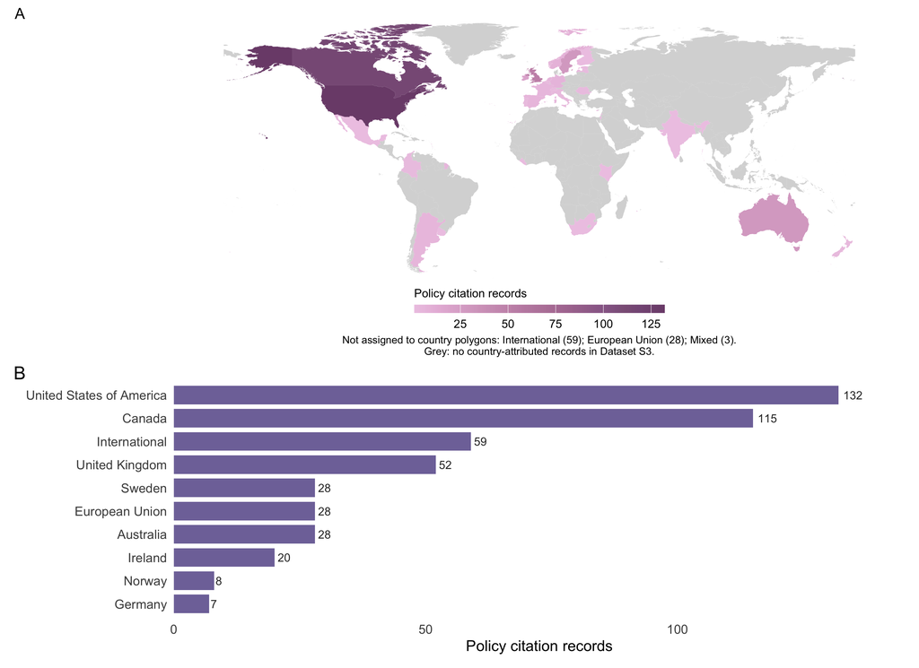

```r
figS10 <- figS10_a + figS10_b + plot_layout(nrow = 2, heights = c(1.1, 1)) +
  plot_annotation(tag_levels = "A")
figS10
```

```r
save_supplementary_figure(here("Figures", "Supplementary", "Figure_S10_geographical_dist_policy.pdf"),
       plot = figS10, bg = "white", width = 11, height = 8)
save_supplementary_figure(here("Figures", "Supplementary", "Figure_S10_geographical_dist_policy.png"),
       plot = figS10, bg = "white", width = 11, height = 8, dpi = 300)
```

# Figure S11: CEESAT scores cited and not cited in policy

## Panel A: CEESAT scores (syntheses cited in policy):

```r
# 1. Labels
labels <- structure(list(q = c("1.1", "2.1", "3.1", "3.2", "4.1", "4.2",
"4.3", "5.1", "5.2", "6.1", "6.2", "6.3", "7.1", "7.2", "7.3",
"8.1"), label = c("1.1 Research question and criteria",
"2.1 A priori protocol", "3.1 Systematic search approach",
"3.2 Search comprehensiveness", "4.1 Defined eligibility criteria",
"4.2 Consistent eligibility criteria",
"4.3 Reported eligibility decisions", "5.1 Critical appraisal",
"5.2 Critical appraisal cross-check",
"6.1 Data extraction method", "6.2 Data availability",
"6.3 Data extraction cross-check",
"7.1 Choice of synthesis approach", "7.2 Appropriate meta-analysis",
"7.3 Variability investigation",
"8.1 Synthesis limitations"
)), row.names = c(NA, -16L), class = c("tbl_df", "tbl", "data.frame"
))


# 2. Prepare the data for BOTH plots
# Data for CITED plot
ceesat_cited_for_plot <- dat_ceesat %>%
  filter(cited_in_policy == 1) %>%
  select(starts_with("CEESAT")) %>%
  mutate(across(c(CEESAT7.2, CEESAT7.3), ~suppressWarnings(as.numeric(.)))) %>%
  pivot_longer(cols = everything(), names_to = "item", values_to = "value") %>%
  group_by(item, value) %>% summarise(n = n(), .groups = "drop") %>%
  group_by(item) %>% mutate(percent = n / sum(n) * 100) %>%
  mutate(q = str_remove(item, "CEESAT")) %>%
  left_join(labels, by = "q") %>%
  mutate(
    value = as.character(value),
    value = ifelse(is.na(value), "NA", value),
    value = factor(value, levels = c("4", "3", "1", "0", "NA"))
  )

# Data for NOT CITED plot
ceesat_not_cited_for_plot <- dat_ceesat %>%
  filter(cited_in_policy == 0) %>%
  select(starts_with("CEESAT")) %>%
  mutate(across(c(CEESAT7.2, CEESAT7.3), ~suppressWarnings(as.numeric(.)))) %>%
  pivot_longer(cols = everything(), names_to = "item", values_to = "value") %>%
  group_by(item, value) %>% summarise(n = n(), .groups = "drop") %>%
  group_by(item) %>% mutate(percent = n / sum(n) * 100) %>%
  mutate(q = str_remove(item, "CEESAT")) %>%
  left_join(labels, by = "q") %>%
  mutate(
    value = as.character(value),
    value = ifelse(is.na(value), "NA", value),
    value = factor(value, levels = c("4", "3", "1", "0", "NA"))
  )


# 3. Create the two plots.
common_theme <- theme_minimal(base_size = 14) +
  theme(
    panel.grid = element_blank(),
    axis.ticks = element_blank(),
    axis.text.x = element_text(size = 14) # Increase percentage label size for both plots
  )

# Plot A: Cited
figS11_a <- ggplot(ceesat_cited_for_plot, aes(x = fct_rev(label), y = percent, fill = value)) +
  geom_col(width = 0.8) +
  geom_text(aes(label = n), position = position_stack(vjust = 0.5), size = 5, color = "black") +
  coord_flip() +
  scale_fill_manual(name = "Score", values = c("0" = "#C73C55", "1" = "#DBA053", "3" = "#7CA982", "4" = "#E6D267"),
                    labels = c("0" = "Red", "1" = "Amber", "3" = "Green", "4" = "Gold")) +
  labs(x = NULL, y = NULL) +
  common_theme +
  # Set the question-label font size.
  theme(axis.text.y = element_text(size = 14))

# Plot B: Not Cited
figS11_b <- ggplot(ceesat_not_cited_for_plot, aes(x = fct_rev(label), y = percent, fill = value)) +
  geom_col(width = 0.8) +
  geom_text(aes(label = n), position = position_stack(vjust = 0.5), size = 5, color = "black") +
  coord_flip() +
  scale_fill_manual(name = "Score", values = c("0" = "#C73C55", "1" = "#DBA053", "3" = "#7CA982", "4" = "#E6D267"),
                    labels = c("NA" = "N/A", "0" = "Red", "1" = "Amber", "3" = "Green", "4" = "Gold")) +
  labs(x = NULL, y = NULL) +
  common_theme +
  theme(axis.text.y = element_blank())
```

## Patchwork- Figure S11 CEESAT

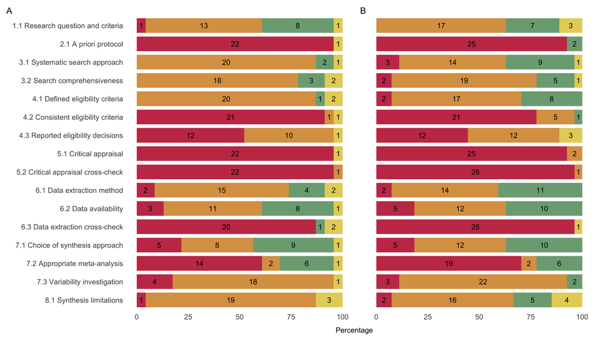

```r
# Combine panels to create figure
figS11 <- (figS11_a | figS11_b) +
  plot_annotation(
    tag_levels = 'A',
    caption = 'Percentage'
  ) &
  theme(
    legend.position = "none",
    plot.caption = element_text(hjust = 0.6, size = 14)
  )

# 5. Display the final combined plot
figS11
```

```r
save_supplementary_figure(here("Figures", "Supplementary", "Figure_S11_CEESATcited_notcited.pdf"), plot = figS11, bg = "white", width = 16, height = 9, dpi= 300)
save_supplementary_figure(here("Figures", "Supplementary", "Figure_S11_CEESATcited_notcited.png"), plot = figS11, bg = "white", width = 16, height = 9, dpi = 300)
```

# R packages

R and package versions used to render this tutorial

| Package | Version |
| --- | --- |
| R | 4.5.1 |
| tidyverse | 2.0.0 |
| here | 1.0.2 |
| paletteer | 1.7.0 |
| scales | 1.4.0 |
| treemapify | 2.6.1 |
| bibliometrix | 5.5.0 |
| ComplexUpset | 1.3.3 |
| patchwork | 1.3.2 |
| wordcloud2 | 0.2.1 |
| sf | 1.1.3 |
| rnaturalearthdata | 1.0.0 |
| rnaturalearth | 1.2.0 |
| ggalluvial | 0.12.6 |
| circlize | 0.4.18 |
| countrycode | 1.9.0 |
| png | 0.1.9 |
| ragg | 1.5.2 |
| ggthemes | 7.0.0 |
| knitr | 1.51 |
| base64enc | 0.1.6 |
| rmarkdown | 2.31 |